# Predicción del tiempo atmosférico

Josep

8/4/2023

```r
# Carga de la librerias
if(!require('dplyr')) install.packages('dplyr'); library('dplyr')
if(!require('tidyverse')) install.packages('tidyverse'); library('tidyverse')
if (!require('cluster')) install.packages('cluster'); library("cluster")
if (!require('dbscan')) install.packages('dbscan'); library("dbscan")
if (!require('C50')) install.packages('C50'); library("C50")
if(!require('caret')) install.packages('caret'); library('caret')
if(!require('class')) install.packages('class'); library('class')
```

**Planteamiento del problema y de los objetivos**

El clima es un fénemeno cambiante y cada vez más dificil de predecir a causa del cambio climático. Sin embargo, la información y las predicciones climáticas sirven como base para la adopción de decisiones en el ámbito de salud pública, gestión del riesgo, agricultura, pesca, gestión del agua, turismo, transporte y energía. Estos sectores necesitan con urgencia información de base científica para planificar sus actividades.

De este modo, el objetivo final de este proyecto de mineria de datos, será construir un modelo capaz de predecir, a partir de una serie de variables si al día siguiente va a llover o no. En este primera parte, se llevará a cabo la elección del conjuto de datos, un analisis inicial, una limpieza, preparación y transformación de estos, para elabrorar y evaluar el modelo final.

**Metodología de resolución**

ANÁLISIS EXPLORATORIO

Queremos hacer una primera aproximación al conjunto de datos escogido y responderemos a las preguntas más básicas:

- ¿Cuánto registros tiene?
- ¿Cuántas variables? ¿De qué tipología son?
- ¿Cómo se distribuyen los valores de las variables?
- ¿Hay problemas con los datos, por ejemplo, campos vacíos?
- ¿Puedo intuir ya el valor analítico de los datos?
- ¿Qué primeras conclusiones puedo extraer?
- ¿Cómo es la relación entre las variables?

PREPARACIÓN DE LOS DATOS

Limpieza

Primero de todo, nos encargaremos de identificar los datos incompletos, redundantes e incorrectos a causa de la transcripción, el contexto y los conceptos de los datos.

- Los valores numéricos perdidos los susutituiremos por la media, moda o eliminaremos, dependiendo de cual sea la mejor decisión para obtener unos datos de calidad.
- Los valores redundantes los eliminamos.

Transformación de los datos

En segundo lugar, efectuaremos una serie de cambios en nuestros datos para que estos puedan ser procesados correctamente por el modelo, además de mejorar su rendimiento.

- La variable Date, la discretizaremos según el estación climatológica y la denominaremos Season con los valores (Invierno, Verano, Primavera y Otono).
- La variables categórticas las tranformaremos en numéricas, para poder aplicar el algoritmo PCA.
- Escalaremos los datos antes de aplicar el algoritmo PCA.

Reducción de dimensionalidad

También es posible que tengamos más registros de los necesarios para conseguir el mismo resultado. En estos casos, lo que se busca es disminuir el número de atributos y registros para reducir el tiempo de ejecución con una calidad de resultados similar.

- Eliminaremos la variable Date y emplearemos la variable Season.
- Comprobaremos la correlación entre diferentes variables y si encontramos algún par de variables altamente correlacionadas, descartaremos una conservando la otra.
- En nuestro caso, vamos a aplicar el algoritmo PCA y elegiremos las compenentes principales que tengan un valor propio mayor que 1 siguiendo el método de Kaiser. Pues un valor propio > 1 indica que los PCs representan más varianza de la que representa una de las variables originales de los datos estandarizados.

DESCRIPCIÓN DEL ORIGEN DEL CONJUTO DE DATOS

Se ha seleccionado un conjunto de datos de [kaggle](https://www.kaggle.com/datasets/jsphyg/weather-dataset-rattle-package), donde la fuente de datos es [Australian Governament](http://www.bom.gov.au/climate/dwo/). El dataset contiene alrededor de 10 años de observaciones atmoféricas de diferentes localizaciones en Australia. Estas observaciones han sido tomadas del sistema Bureau of Meteorology’s.La mayoría de los datos se generan y manejan automáticamente. El objetivo analitico es enteder que fenómenos atmoféricos son los más importantes para predicir si al día siguiente lloverá. Este dataset nos permitirá llevar a cabo nuestro objetivo, además se puede aplicar tanto a modelos supervisado, no supervisado y de asociación, ya que contiene la variable dependiente “RainTomorrow”, que en los modelos no supervisados deberemos de eliminar.

**ANÁLISIS EXPLORATORIO**

El primer paso para realizar un análisis exploratorio es cargar el fichero de datos.

```r
datos <- read.csv('weatherAUS.csv')
head(datos)
```

```
##         Date Location MinTemp MaxTemp Rainfall Evaporation Sunshine WindGustDir
## 1 2008-12-01   Albury    13.4    22.9      0.6          NA       NA           W
## 2 2008-12-02   Albury     7.4    25.1      0.0          NA       NA         WNW
## 3 2008-12-03   Albury    12.9    25.7      0.0          NA       NA         WSW
## 4 2008-12-04   Albury     9.2    28.0      0.0          NA       NA          NE
## 5 2008-12-05   Albury    17.5    32.3      1.0          NA       NA           W
## 6 2008-12-06   Albury    14.6    29.7      0.2          NA       NA         WNW
##   WindGustSpeed WindDir9am WindDir3pm WindSpeed9am WindSpeed3pm Humidity9am
## 1            44          W        WNW           20           24          71
## 2            44        NNW        WSW            4           22          44
## 3            46          W        WSW           19           26          38
## 4            24         SE          E           11            9          45
## 5            41        ENE         NW            7           20          82
## 6            56          W          W           19           24          55
##   Humidity3pm Pressure9am Pressure3pm Cloud9am Cloud3pm Temp9am Temp3pm
## 1          22      1007.7      1007.1        8       NA    16.9    21.8
## 2          25      1010.6      1007.8       NA       NA    17.2    24.3
## 3          30      1007.6      1008.7       NA        2    21.0    23.2
## 4          16      1017.6      1012.8       NA       NA    18.1    26.5
## 5          33      1010.8      1006.0        7        8    17.8    29.7
## 6          23      1009.2      1005.4       NA       NA    20.6    28.9
##   RainToday RainTomorrow
## 1        No           No
## 2        No           No
## 3        No           No
## 4        No           No
## 5        No           No
## 6        No           No
```

Verificamos la estructura del juego de datos principal. Vemos el número de columnas que tenemos y ejemplos de los contenidos de las filas.

```r
str(datos)
```

```
## 'data.frame':    145460 obs. of  23 variables:
##  $ Date         : chr  "2008-12-01" "2008-12-02" "2008-12-03" "2008-12-04" ...
##  $ Location     : chr  "Albury" "Albury" "Albury" "Albury" ...
##  $ MinTemp      : num  13.4 7.4 12.9 9.2 17.5 14.6 14.3 7.7 9.7 13.1 ...
##  $ MaxTemp      : num  22.9 25.1 25.7 28 32.3 29.7 25 26.7 31.9 30.1 ...
##  $ Rainfall     : num  0.6 0 0 0 1 0.2 0 0 0 1.4 ...
##  $ Evaporation  : num  NA NA NA NA NA NA NA NA NA NA ...
##  $ Sunshine     : num  NA NA NA NA NA NA NA NA NA NA ...
##  $ WindGustDir  : chr  "W" "WNW" "WSW" "NE" ...
##  $ WindGustSpeed: int  44 44 46 24 41 56 50 35 80 28 ...
##  $ WindDir9am   : chr  "W" "NNW" "W" "SE" ...
##  $ WindDir3pm   : chr  "WNW" "WSW" "WSW" "E" ...
##  $ WindSpeed9am : int  20 4 19 11 7 19 20 6 7 15 ...
##  $ WindSpeed3pm : int  24 22 26 9 20 24 24 17 28 11 ...
##  $ Humidity9am  : int  71 44 38 45 82 55 49 48 42 58 ...
##  $ Humidity3pm  : int  22 25 30 16 33 23 19 19 9 27 ...
##  $ Pressure9am  : num  1008 1011 1008 1018 1011 ...
##  $ Pressure3pm  : num  1007 1008 1009 1013 1006 ...
##  $ Cloud9am     : int  8 NA NA NA 7 NA 1 NA NA NA ...
##  $ Cloud3pm     : int  NA NA 2 NA 8 NA NA NA NA NA ...
##  $ Temp9am      : num  16.9 17.2 21 18.1 17.8 20.6 18.1 16.3 18.3 20.1 ...
##  $ Temp3pm      : num  21.8 24.3 23.2 26.5 29.7 28.9 24.6 25.5 30.2 28.2 ...
##  $ RainToday    : chr  "No" "No" "No" "No" ...
##  $ RainTomorrow : chr  "No" "No" "No" "No" ...
```

Vemos que tenemos **23** variables y **145460** registros

Revisamos la descripción de las variables contenidas en el fichero y si los tipos de variables se corresponden con las que hemos cargado. Explicación variables del dataset

- Date -> Fecha de la observación (Categórica)
- Location -> Nombre de la localización donde se encuentra la estación meteorológica (Categórica)
- MinTemp -> Temperatura mínima en grados celsius (Numérica)
- MaxTemp -> Temperatura máxima en grados celsius (Numérica)
- Rainfall -> Cantidad de lluvia recogida para el día en milímetros (Numérica)
- Evaporation -> Evaporación de clase A en las 24h recogida a las 9 a.m (Numérica)
- Sunshine -> Horas de sol en el día (Numérica)
- WindGustDir -> Dirección de la ráfaga de viento en el día (Categórica)
- WindGustSpeed -> Velocidad en (km/h) de la ráfaga de viento más rápida (Numérica)
- WindDir9am -> Dirección del viento a las 9 a.m (Categórica)
- WindDir3pm -> Dirección del viento a las 3 p.m (Categórica)
- WindSpeed9am -> Velocidad del viento en (km/h) promediada durante 10 minutos antes de las 9 a.m (Numérica)
- WindSpeed3pm -> Velocidad del viento en (km/h) promediada durante 10 minutos antes de las 3 p.m (Numérica)
- Humidity9am -> Porcentaje de humedad a las 9 a.m (Numérica)
- Humidity3pm -> Porcentaje de humedad a las 3 p.m (Numérica)
- Pressure9am -> Presión atmoférica en hectopasacales reduciada al nivel medio del mar a las 9 a.m (Numérica)
- Pressure3pm -> Presión atmoférica en hectopasacales reduciada al nivel medio del mar a las 3 p.m (Numérica)
- Cloud9am -> Fracción de cielo oscurecida por nubes a las 9 a.m. Esto se mide en “octas”, que son una unidad de octavos. Registra cuántos octavos del cielo están oscurecidos por las nubes. Una medida de 0 indica cielo completamente despejado mientras que un 8 indica que está completamente nublado. (Numérica)
- Cloud3pm -> Fracción de cielo oscurecida por nubes a las 3 p.m. Esto se mide en “octas”, que son una unidad de octavos. Registra cuántos octavos del cielo están oscurecidos por las nubes. Una medida de 0 indica cielo completamente despejado mientras que un 8 indica que está completamente nublado. (Numérica)
- Temp9am -> Temperatura en grados celsius a las 9 a.m (Numérica)
- Temp3pm -> Temperatura en grados celsius a las 3 p.m (Numérica)
- RainToday -> YES si la precipitación (mm) en las 24 horas hasta las 9 am excede 1 mm, de lo contrario NO. (Binaria)
- RainTomorrow -> YES si al dia siguiente llovió, de los contrario NO. (Binaria)

```r
# Carga de la librerias
if(!require('dplyr')) install.packages('dplyr'); library('dplyr')
if(!require('tidyverse')) install.packages('tidyverse'); library('tidyverse')
if (!require('ggplot2')) install.packages('ggplot2'); library('ggplot2')
if(!require("corrplot")) install.packages("corrplot"); library("corrplot")
if (!require('factoextra')) install.packages('factoextra'); library('factoextra')
if (!require('smotefamily')) install.packages('smotefamily'); library('smotefamily')
```

**PREPROCESAMIENTO Y GESTIÓN DE LAS VARIABLES**

LIMPIEZA

Comprobamos cuantos valores nulos tenemos en cada una de las columnas

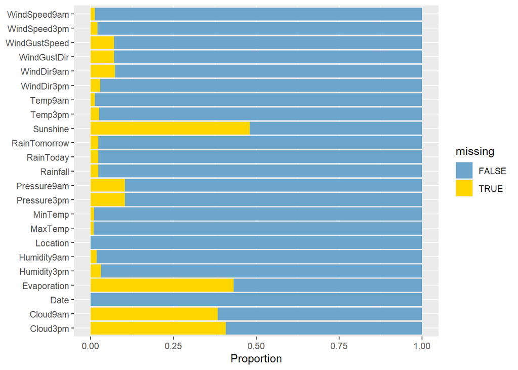

```r
datos  %>%
  summarise_all(list(~is.na(.)))%>%
  pivot_longer(everything(),
               names_to = "variables", values_to="missing") %>%
  count(variables, missing) %>%
  ggplot(aes(y=variables,x=n,fill=missing))+
  geom_col(position = "fill")+
  labs(x="Proportion")+
  scale_fill_manual(values=c("skyblue3","gold"))+
  theme(axis.title.y=element_blank())
```

Observamos que las cuatro columnas tienen una tasa de datos faltantes inferior al 50 %. En lugar de ignorarlos, los incorporaremos a nuestro modelo a través de la imputación adecuada. Para decidir qué metodo usar para sustituir los valores de NaN, extraeremos las características numéricas. Dependiendo de su distribución vamos a reemplazar con mediana o media. Sin embargo, dado que los valores que faltan en estos son bastante grandes, decidimos descartar todos los valores de NaN en lugar de sustituirlos con el método de la moda para evitar el overfitting.

Eliminamos los valores nulos

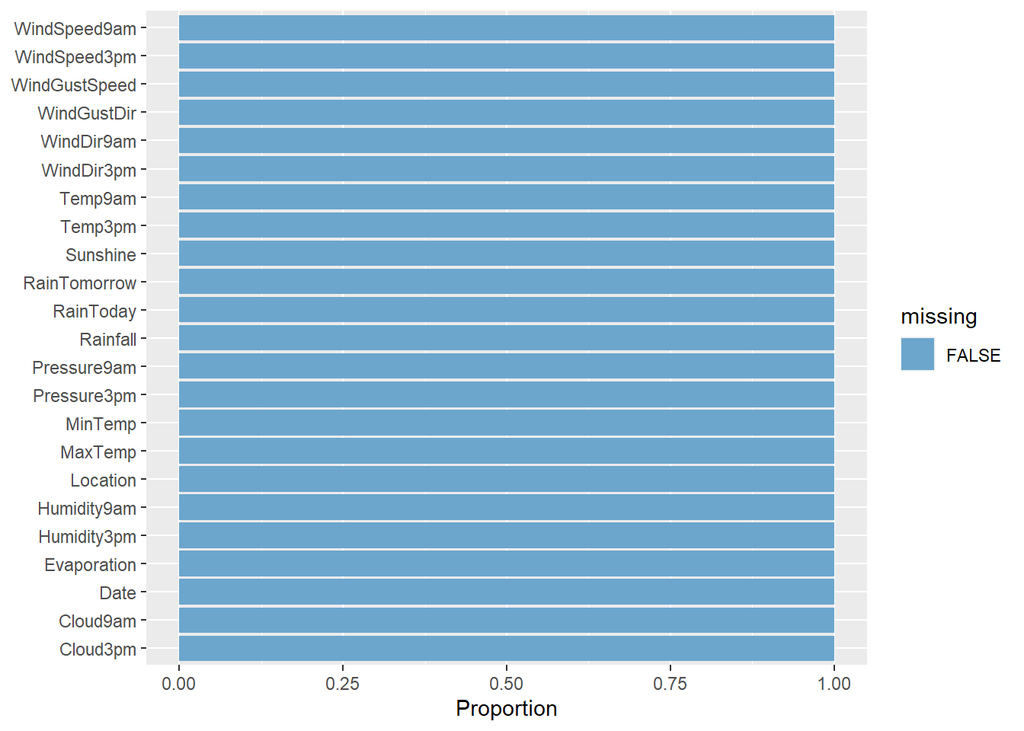

```r
# Eliminamos los nulos con la función drop_na()
datos_clean <- datos %>%
  drop_na()

# Mostramos si tenemos valores nulos
datos_clean  %>%
  summarise_all(list(~is.na(.)))%>%
  pivot_longer(everything(),
               names_to = "variables", values_to="missing") %>%
  count(variables, missing) %>%
  ggplot(aes(y=variables,x=n,fill=missing))+
  geom_col(position = "fill")+
  labs(x="Proportion")+
  scale_fill_manual(values=c("skyblue3","gold"))+
  theme(axis.title.y=element_blank())
```

Eliminamos las filas duplicadas

```r
print(dim(datos_clean))
```

```
## [1] 56420    23
```

```r
# Las eliminasmo con la función distinct()
datos_clean <- datos_clean %>%
  distinct()
print(dim(datos_clean))
```

```
## [1] 56420    23
```

Comprobamos que no teníamos ningun valor duplicado

Ya no tenemos valores nulos y los datos esán listos para el análisis de sus distribuciones y relaciones.

**ANÁLISIS DE LAS DISTRIBUCIONES**

```r
summary(datos_clean[c("Rainfall", "Sunshine", "Temp3pm", "Temp9am", "WindSpeed9am")])
```

```
##     Rainfall         Sunshine         Temp3pm         Temp9am
##  Min.   :  0.00   Min.   : 0.000   Min.   : 3.70   Min.   :-0.7
##  1st Qu.:  0.00   1st Qu.: 5.000   1st Qu.:17.40   1st Qu.:13.1
##  Median :  0.00   Median : 8.600   Median :22.40   Median :17.8
##  Mean   :  2.13   Mean   : 7.736   Mean   :22.71   Mean   :18.2
##  3rd Qu.:  0.60   3rd Qu.:10.700   3rd Qu.:27.90   3rd Qu.:23.3
##  Max.   :206.20   Max.   :14.500   Max.   :46.10   Max.   :39.4
##   WindSpeed9am
##  Min.   : 2.00
##  1st Qu.: 9.00
##  Median :15.00
##  Mean   :15.67
##  3rd Qu.:20.00
##  Max.   :67.00
```

**Lluvia**

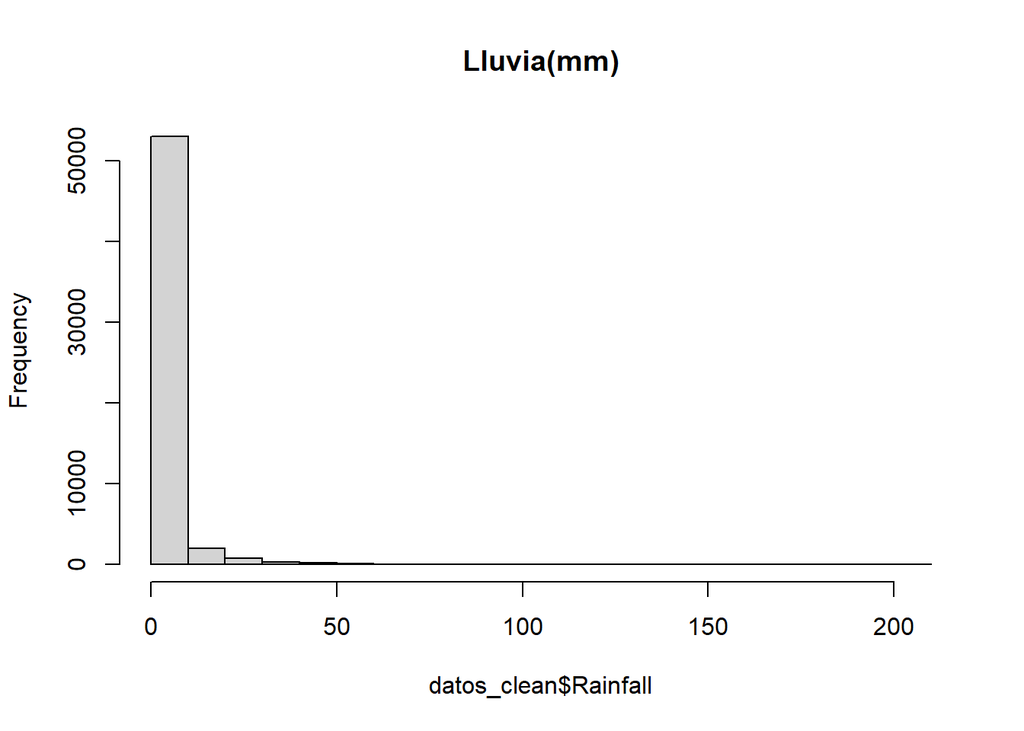

```r
# Distribución de la lluvia
hist(datos_clean$Rainfall, main = 'Lluvia(mm)')
```

La columna ‘Rainfall’ parece tener un solo pico con el valor de Precipitaciones en ‘0’. Esto significa que la mayoría de los días en Australia no llueve. Si llueve, es una precipitación muy ligera con un valor medio de 2.13 milímetros de lluvia. La precipitación más intensa registrada en Australia fue de 206,2 milímetros. Aunque la distribución de datos parece incorrecta, esto es normal para los datos recopilados sobre precipitaciones.

Por el t-test, vamos a comprobar si sus medias son siginificativamente diferentes en función de la variable dependiente (RainTomorrow). Podemos aplicar el t-test, ya que al tener mas de 30 registros, por el Teorema del Límite Central podemos asumir que tiene una distribución normal.

```r
t.test(datos_clean$Rainfall ~ datos_clean$RainTomorrow)
```

```
##
##  Welch Two Sample t-test
##
## data:  datos_clean$Rainfall by datos_clean$RainTomorrow
## t = -40.631, df = 13565, p-value < 2.2e-16
## alternative hypothesis: true difference in means between group No and group Yes is not equal to 0
## 95 percent confidence interval:
##  -4.512842 -4.097463
## sample estimates:
##  mean in group No mean in group Yes
##          1.182149          5.487302
```

Como el p-value es prácticamente cero, podemos confirmar que las medias son significativamnete diferentes. Por tanto, es posible que esta información sea importante para entender una de las causas de la lluvía.

**Horas de sol**

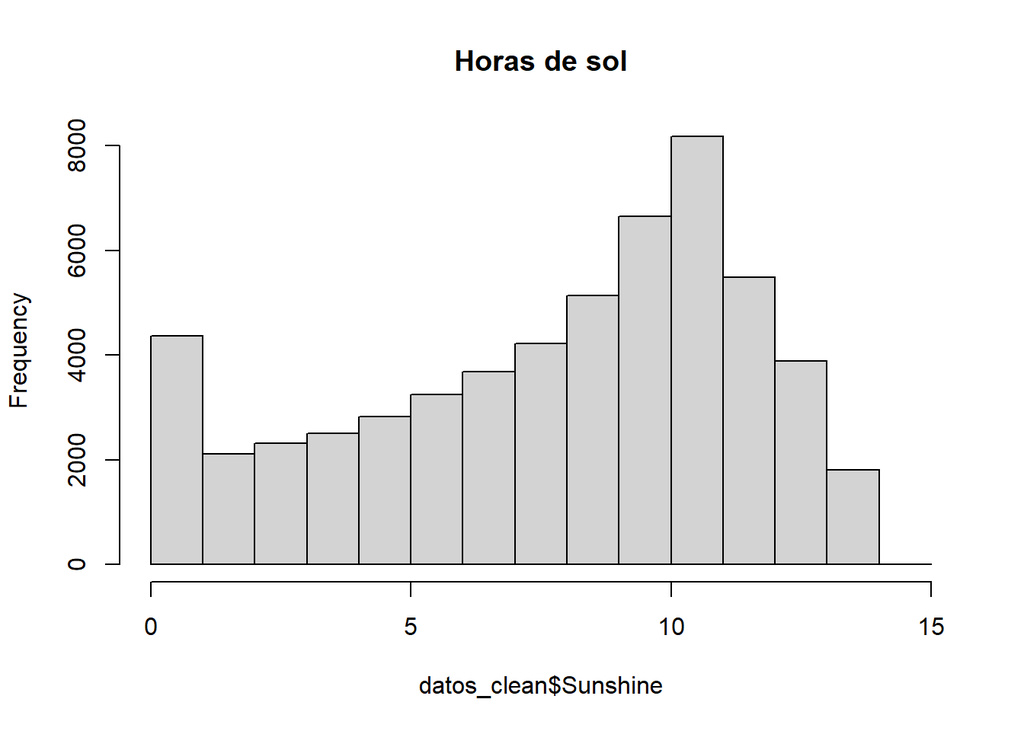

```r
# Distribución Sunshine
hist(datos_clean$Sunshine, main = 'Horas de sol')
```

La columna ‘Sunshine’ parece tener una distribución bimodal con dos picos. Los picos nos dicen que hay algunos días en Australia en los que no hay sol, como en condiciones de tiempo nublado. Aunque haya un pico en 0 horas de sol, no significa que sea un valor erróneo ya que tiene sentido que haya días con 0 horas de sol. Esto significa que los datos son lo suficientemente fiables.

Por el t-test, vamos a comprobar si sus medias son siginificativamente diferentes en función de la variable dependiente (RainTomorrow). Podemos aplicar el t-test, ya que al tener mas de 30 registros, por el Teorema del Límite Central podemos asumir que tiene una distribución normal.

```r
t.test(datos_clean$Sunshine ~ datos_clean$RainTomorrow)
```

```
##
##  Welch Two Sample t-test
##
## data:  datos_clean$Sunshine by datos_clean$RainTomorrow
## t = 119.78, df = 19745, p-value < 2.2e-16
## alternative hypothesis: true difference in means between group No and group Yes is not equal to 0
## 95 percent confidence interval:
##  4.044376 4.178939
## sample estimates:
##  mean in group No mean in group Yes
##          8.641254          4.529597
```

Como el p-value es prácticamente cero, podemos confirmar que las medias son significativamnete diferentes. Por tanto, es posible que esta información sea importante para entender una de las causas de la lluvía.

**Temperatura a las 9 a.m (ºC)**

```r
# Desviación típca de la Temperatura a las 9 a.m
print(sd(datos_clean$Temp9am))
```

```
## [1] 6.567991
```

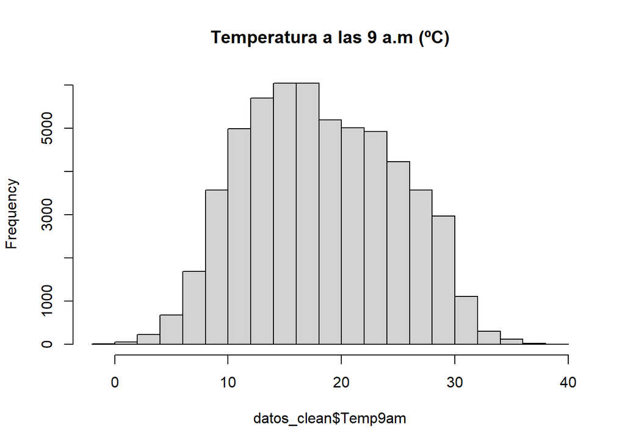

```r
# Distribución de la Temperatura a las 9 a.m
hist(datos_clean$Temp9am, main = 'Temperatura a las 9 a.m (ºC)')
```

La columna ‘Temp9am’ parece tener una distribución normal sin valores atípicos visibles, esto se puede ver en la curva en forma de campana de nuestro histograma. El valor esperado es de 18 grados con una variación de + o - 6 grados centígrados, esto también es normal para la temperatura a las 9 am en Australia, lo que indica que esta columna no tiene errores visibles.

Por el t-test, vamos a comprobar si sus medias son siginificativamente diferentes en función de la variable dependiente (RainTomorrow). Podemos aplicar el t-test, ya que al tener mas de 30 registros, por el Teorema del Límite Central podemos asumir que tiene una distribución normal.

```r
t.test(datos_clean$Temp9am ~ datos_clean$RainTomorrow)
```

```
##
##  Welch Two Sample t-test
##
## data:  datos_clean$Temp9am by datos_clean$RainTomorrow
## t = 4.3032, df = 19886, p-value = 1.692e-05
## alternative hypothesis: true difference in means between group No and group Yes is not equal to 0
## 95 percent confidence interval:
##  0.1568769 0.4193450
## sample estimates:
##  mean in group No mean in group Yes
##          18.26842          17.98031
```

Como el p-value < 0.05 , podemos confirmar que las medias son significativamnete diferentes. Por tanto, es posible que esta información sea importante para entender una de las causas de la lluvía.

**Temperatura a las 3 p.m (ºC)**

```r
# Desviación típca de la Temperatura a las 3 p.m
print(sd(datos_clean$Temp3pm))
```

```
## [1] 6.836543
```

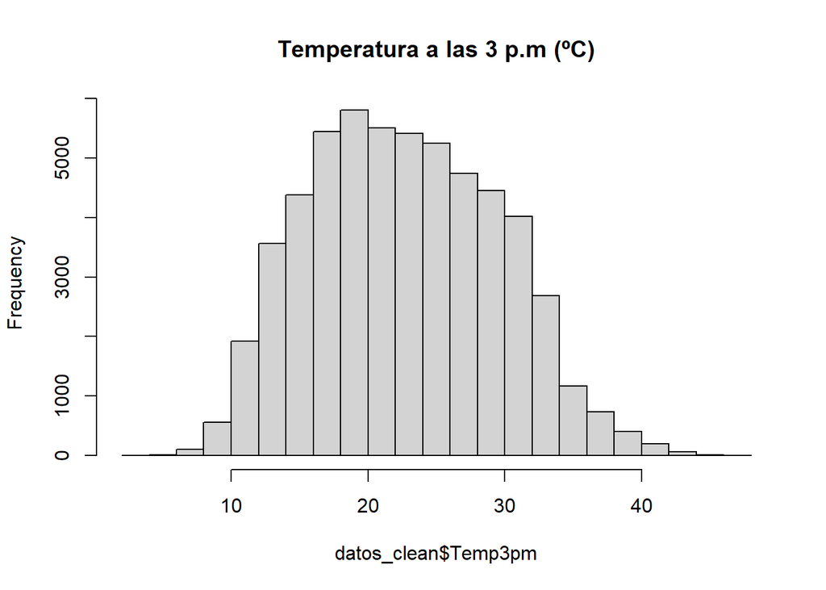

```r
# Distribución de la Temperatura a las 9 p.m
hist(datos_clean$Temp3pm, main = 'Temperatura a las 3 p.m (ºC)')
```

La columna ‘Temp3pm’ parece tener una distribución normal sin valores atípicos visibles, esto se puede ver en la curva en forma de campana de nuestro histograma. El valor esperado es de 22 grados con una variación de + o - 6 grados centígrados, la temperatura media es más alta que la de las 9 am puede deberse a que la luz del sol está más presente a las 3 pm, lo que indica que esta columna no tiene errores visibles.

Por el t-test, vamos a comprobar si sus medias son siginificativamente diferentes en función de la variable dependiente (RainTomorrow). Podemos aplicar el t-test, ya que al tener mas de 30 registros, por el Teorema del Límite Central podemos asumir que tiene una distribución normal.

```r
t.test(datos_clean$Temp3pm ~ datos_clean$RainTomorrow)
```

```
##
##  Welch Two Sample t-test
##
## data:  datos_clean$Temp3pm by datos_clean$RainTomorrow
## t = 44.399, df = 20012, p-value < 2.2e-16
## alternative hypothesis: true difference in means between group No and group Yes is not equal to 0
## 95 percent confidence interval:
##  2.894822 3.162223
## sample estimates:
##  mean in group No mean in group Yes
##          23.37739          20.34887
```

Como el p-value es prácticamente cero, podemos confirmar que las medias son significativamnete diferentes. Por tanto, es posible que esta información sea importante para entender una de las causas de la lluvía.

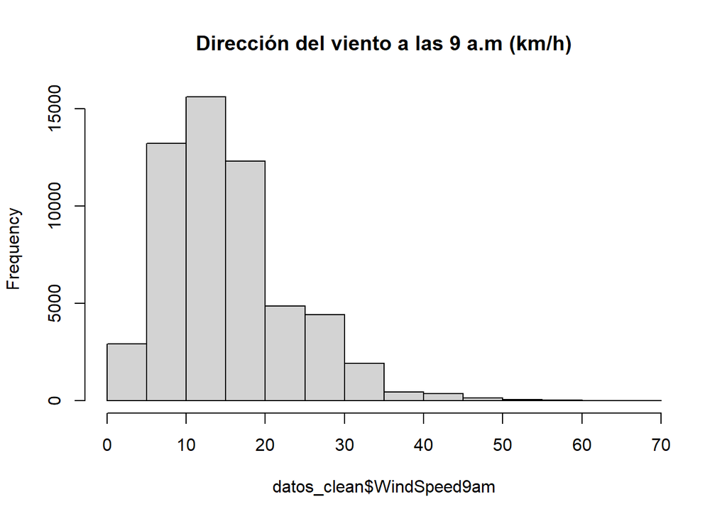

```r
# Distribución de la Temperatura a las 9 a.m
hist(datos_clean$WindSpeed9am, main = 'Dirección del viento a las 9 a.m (km/h)')
```

La columna ‘WindSpeed9am’ tiene una asimetría positiva (cola a derecha). El valor esperado es de 15 km/h, los valores más altos pueden deberse a las ráfagas de viento, lo que indica que esta columna no tiene errores visibles.

Por el t-test, vamos a comprobar si sus medias son siginificativamente diferentes en función de la variable dependiente (RainTomorrow). Podemos aplicar el t-test, ya que al tener mas de 30 registros, por el Teorema del Límite Central podemos asumir que tiene una distribución normal.

```r
t.test(datos_clean$WindSpeed9am ~ datos_clean$RainTomorrow)
```

```
##
##  Welch Two Sample t-test
##
## data:  datos_clean$WindSpeed9am by datos_clean$RainTomorrow
## t = -18.777, df = 18391, p-value < 2.2e-16
## alternative hypothesis: true difference in means between group No and group Yes is not equal to 0
## 95 percent confidence interval:
##  -1.859641 -1.508083
## sample estimates:
##  mean in group No mean in group Yes
##          15.29634          16.98020
```

Como el p-value es prácticamente cero, podemos confirmar que las medias son significativamnete diferentes. Por tanto, es posible que esta información sea importante para entender una de las causas de la lluvía.

**Dirección del viento**

Queremos comprobar las proporciones de WindGustDir (datos categóricos)

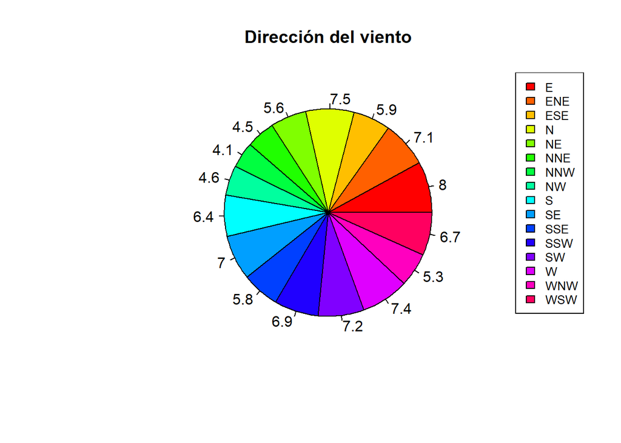

```r
# Obtenemos el recuento de cada uno de los tipo de viento
wind_dir <- datos_clean %>%
  count(WindGustDir)

# Obtenemos el porcentaje de cada tipo de viento
piepercent<- round(100*wind_dir$n/sum(wind_dir$n), 1)

# Creamos el grafico de sectores
pie(wind_dir$n, labels = piepercent, main = "Dirección del viento",col = rainbow(length(wind_dir$WindGustDir)))
legend("topright", c("E","ENE","ESE","N","NE","NNE","NNW","NW","S","SE","SSE","SSW","SW","W","WNW","WSW"), cex = 0.8,
   fill = rainbow(length(wind_dir$WindGustDir)))
```

Desde el gráfico de sectores, los datos de WindGustDir están distribuidos de manera bastante uniforme, no hay anomalías ni direcciones dominantes.

Ahora comprobamos si existe algún tipo de dependecia entre la variable WindGustDir y nuestra variable dependiente “RainTomorrow”. Como se trata de dos variables categóricas empleamos el test de chi-cuadrado y al tener mas de 30 registros, por el Teorema del Límite Central podemos asumir que tiene una distribución normal.

```r
chisq.test(datos_clean$WindGustDir, datos_clean$RainTomorrow)
```

```
##
##  Pearson's Chi-squared test
##
## data:  datos_clean$WindGustDir and datos_clean$RainTomorrow
## X-squared = 745.55, df = 15, p-value < 2.2e-16
```

Como el p-value < 0.05, podemos rechazar la hipótesis nula y concluir que la variable “RainTomorrow” es decir, si llueve mañana, puede depender de la dirección del viento.

**ANÁLISIS DE LAS RELACIÓN DE LAS VARIABLES DE NUESTRO DATASET**

Definiciones:

- Correlación positiva: las variables tienen una relación que se mueve en la misma dirección, por ejemplo, aumentar la variable A también aumentará la variable B si la correlación entre A y B es positiva.
- Correlación negativa: las variables tienen una relación, esto indica que al aumentar la variable A disminuirá la variable B si la correlación entre A y B es negativa.
- Correlación cero: sin relación lineal entre las variables, el valor de la variable B no cambia en función del valor de la variable A.

**Relación entre la temperatura máxima (MaxTemp) y la evaporación (Evaporation)**

Hipótesis: Existe una fuerte relación entre la temperatura máxima y la evaporación. Cuanto mayor sea la temperatura máxima, mayor será la tasa de evaporación, lo que indica una correlación positiva.

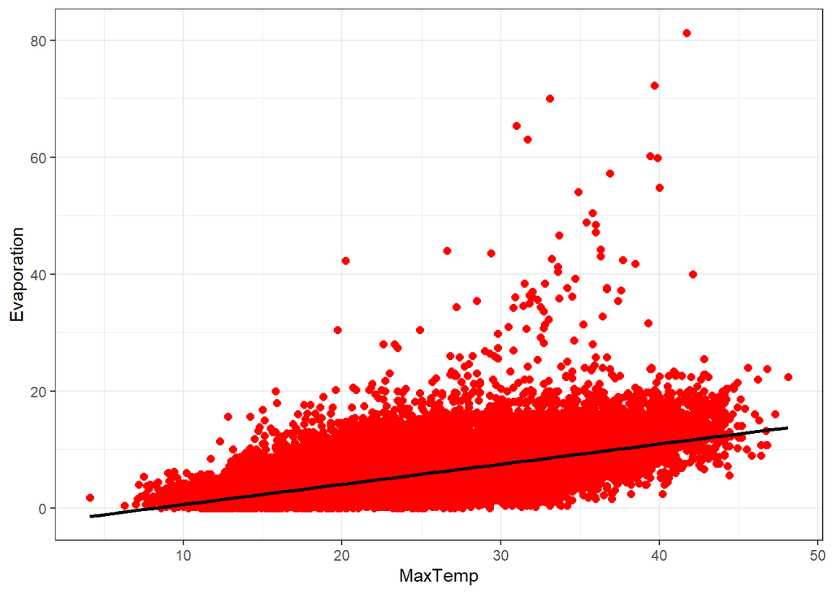

```r
# Creamos el gráfico de dispersión y añadimos la línea que mejor ajusta al gráfico de dispersión
ggplot(datos_clean, aes(x=MaxTemp, y=Evaporation)) +
    geom_point(col='red', size=2) +
    geom_smooth(method=lm, se=FALSE, col='black') +
    theme_bw()
```

```r
# Mostramos numéricamnete la correlación
print(cor(datos_clean$MaxTemp, datos_clean$Evaporation))
```

```
## [1] 0.6509644
```

Como se ve en el diagrama de dispersión y en el resultado de la correlación, podemos inferir que existe una correlación positiva entre la temperatura máxima y la evaporación. Cuanto mayor sea la temperatura máxima, mayor será el valor de la evaporación. Esto se relaciona con el razonamiento científico de que el agua se evapora más rápido cuando la temperatura es alta.

**Relación entre la lluvia (Rainfall) y la evaporación (Evaporation)**

Hipótesis: Existe una fuerte relación entre la Evaporación y la Precipitación. Cuanto mayor sea el valor de Evaporación, mayor será el valor de Precipitación, lo que indica una correlación positiva.

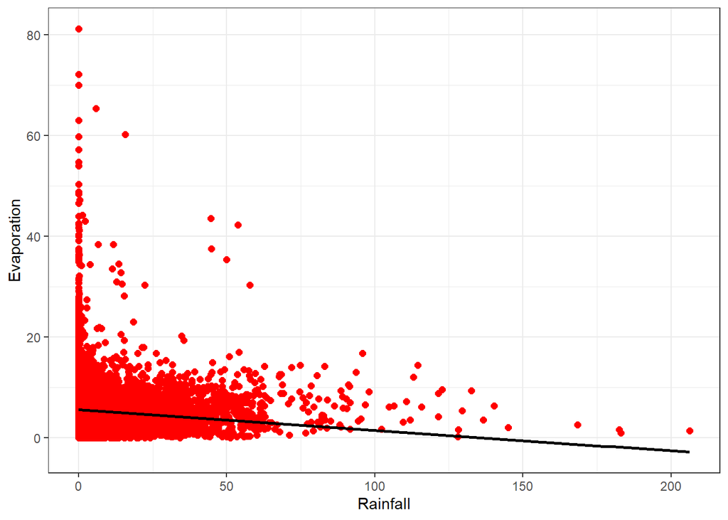

```r
# Creamos el gráfico de dispersión y añadimos la línea que mejor ajusta al gráfico de dispersión
ggplot(datos_clean, aes(x=Rainfall, y=Evaporation)) +
    geom_point(col='red', size=2) +
    geom_smooth(method=lm, se=FALSE, col='black') +
    theme_bw()
```

```r
# Mostramos numéricamnete la correlación
print(cor(datos_clean$Rainfall, datos_clean$Evaporation))
```

```
## [1] -0.07723881
```

Como podemos ver en el diagrama de dispersión y en el resultado de la correlación, existe una correlación negativa y muy baja entre la evaporación y la lluvia. Esto puede deberse al hecho de que la mayoría de los datos de lluvia están entre 0 y 30. Debido a los razonamientos científicos, esperábamos que la evaporación jugara un papel importante en la contribución a la lluvia, sin embargo, este gráfico nos muestra que puede haber otros factores que afectan lluvia fuera de la evaporación.

**Relación entre la insolación (Sunshine) y temperatura a las 3 p.m (Temp3pm)**

Hipótesis: Suponemos que existe una correlación positiva entre la luz solar y la temperatura a las 3:00 p. m., cuando la exposición a la luz solar es máxima.

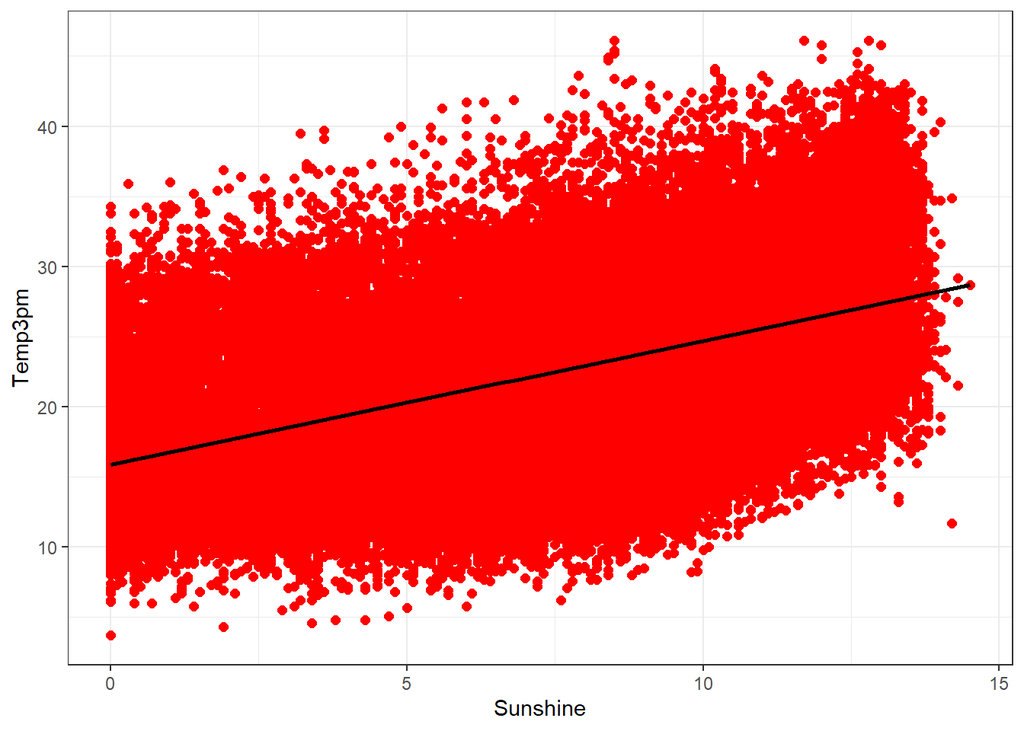

```r
# Creamos el gráfico de dispersión y añadimos la línea que mejor ajusta al gráfico de dispersión
ggplot(datos_clean, aes(x=Sunshine, y=Temp3pm)) +
    geom_point(col='red', size=2) +
    geom_smooth(method=lm, se=FALSE, col='black') +
    theme_bw()
```

```r
# Mostramos numéricamnete la correlación
print(cor(datos_clean$Sunshine, datos_clean$Temp3pm))
```

```
## [1] 0.486129
```

Como podemos ver en el diagrama de dispersión y en el resultado de la correlación, existe una correlación positiva entre la luz solar y la temperatura a las 3 p. m. Esto nos dice que cuanto más sol hay, más alta es la temperatura a las 3 de la tarde. Esto tiene sentido científicamente ya que la luz del sol emite calor que a su vez aumenta la temperatura atmosférica general.

**Relación entre la temperatura mínima (MinTemp) y la humedad (Humidity9am)**

Hipótesis: Suponemos que existe una correlación negativa entre la temperatura y la humedad. Creemos que cuanto menor sea la temperatura, mayor será el nivel de humedad.

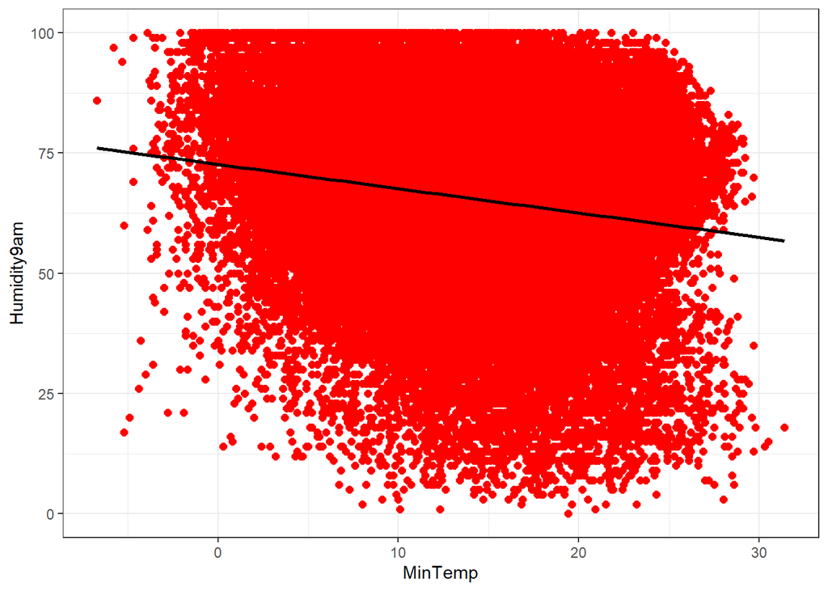

```r
# Creamos el gráfico de dispersión y añadimos la línea que mejor ajusta al gráfico de dispersión
ggplot(datos_clean, aes(x=MinTemp, y=Humidity9am)) +
    geom_point(col='red', size=2) +
    geom_smooth(method=lm, se=FALSE, col='black') +
    theme_bw()
```

```r
# Mostramos numéricamnete la correlación
print(cor(datos_clean$MinTemp, datos_clean$Humidity9am))
```

```
## [1] -0.1749913
```

Como podemos ver en el diagrama de dispersión y en el resultado de la correlación, existe una correlación negativa entre la temperatura mínima y humedad. La relación entre la humedad y la temperatura son inversamente proporcionales. Si la temperatura aumenta, dará lugar a una disminución de la humedad relativa, por lo que el aire se volverá más seco, mientras que cuando la temperatura disminuya, el aire se humedecerá, lo que significa que la humedad relativa aumentará.

**Relación entre la insolación (Sunshine) y la humedad a las 3pm (Humidity3pm)**

Hipótesis: pensamos que tendrán una correlación negativa, ya que creemos que cuantas más horas de sol, menor sera la humedad.

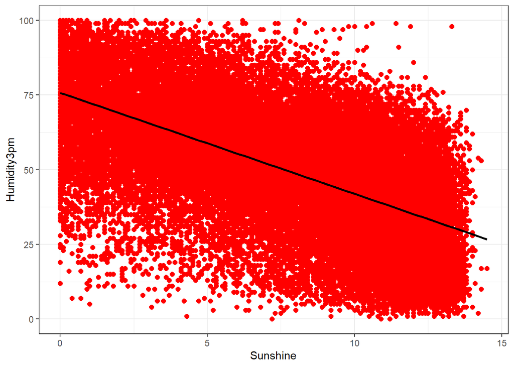

```r
# Creamos el gráfico de dispersión y añadimos la línea que mejor ajusta al gráfico de dispersión
ggplot(datos_clean, aes(x=Sunshine, y=Humidity3pm)) +
    geom_point(col='red', size=2) +
    geom_smooth(method=lm, se=FALSE, col='black') +
    theme_bw()
```

```r
# Mostramos numéricamnete la correlación
print(cor(datos_clean$Sunshine, datos_clean$Humidity3pm))
```

```
## [1] -0.6292987
```

Como podemos ver en el diagrama de dispersión, existe una correlación negativa y fuerte entre la insolación y humedad. La relación entre la humedad y la insolación son inversamente proporcionales. Si la insolación aumenta, por norma general la tempertura aumenta y como antes habiamos comprobado dará lugar a una disminución de la humedad relativa, y el aire se volverá más seco, mientras que cuando la insolación disminuya, el aire se humedecerá, lo que significa que la humedad relativa aumentará.

**TRANSFORMACIÓN DE LOS DATOS**

Discretización de la variable Date

```r
# Iteremos por cada año y le añadimos la etiqueta correcta de la estación para dicha fecha

for(i in seq(2007,2017)){
   datos_clean[format(as.Date(datos_clean$Date, format="%Y-%m-%d"),"%Y") == i, "Season"] <-  cut(strptime(datos_clean[format(as.Date(datos_clean$Date, format="%Y-%m-%d"),"%Y") == i, "Date"], format = '%Y-%m-%d'),
  breaks = strptime(
    c(as.Date(paste(as.character(i), '-01-01', sep = ""), format = '%Y-%m-%d'),
      as.Date(paste(as.character(i), '-02-28', sep = ""), format = '%Y-%m-%d'),
      as.Date(paste(as.character(i), '-05-31', sep = ""), format = '%Y-%m-%d'),
      as.Date(paste(as.character(i), '-08-31', sep = ""), format = '%Y-%m-%d'),
      as.Date(paste(as.character(i), '-11-30', sep = ""), format = '%Y-%m-%d'),
      as.Date(paste(as.character(i+1), '-01-01', sep = ""), format = '%Y-%m-%d')), format = '%Y-%m-%d'),
    labels = c('Verano', 'Otoño', 'Invierno', 'Primavera', 'Verano'))
}
```

Queremos transformar las columnas de tipo character y binario a tipo numérico para poder calcular la matriz de correlación, hacer resampling y finalmente aplicar el algoritmo PCA

```r
# Columnas binarias
datos_clean$RainTomorrow <- ifelse(datos_clean$RainTomorrow == 'Yes', 1,0)
datos_clean$RainToday <- ifelse(datos_clean$RainToday == 'Yes', 1,0)

# Columnas categóricas
datos_clean$Location <- as.integer(factor(datos_clean$Location))
datos_clean$WindDir9am <- as.integer(factor(datos_clean$WindDir9am))
datos_clean$WindDir3pm <- as.integer(factor(datos_clean$WindDir3pm))
datos_clean$WindGustDir <- as.integer(factor(datos_clean$WindGustDir))
datos_clean$Season <- as.integer(datos_clean$Season)
```

**REDUCCIÓN DE LA DIMENSIONALIDAD**

Eliminamos la columna con la fecha que no la emplearemos en nuestr0 análisis

```r
datos_final <- dplyr::select(datos_clean, -Date)
```

Comprobamos la correlación entre diferentes variables, y si encontramos algún par de variables altamente correlacionadas, descartaremos una conservando la otra.

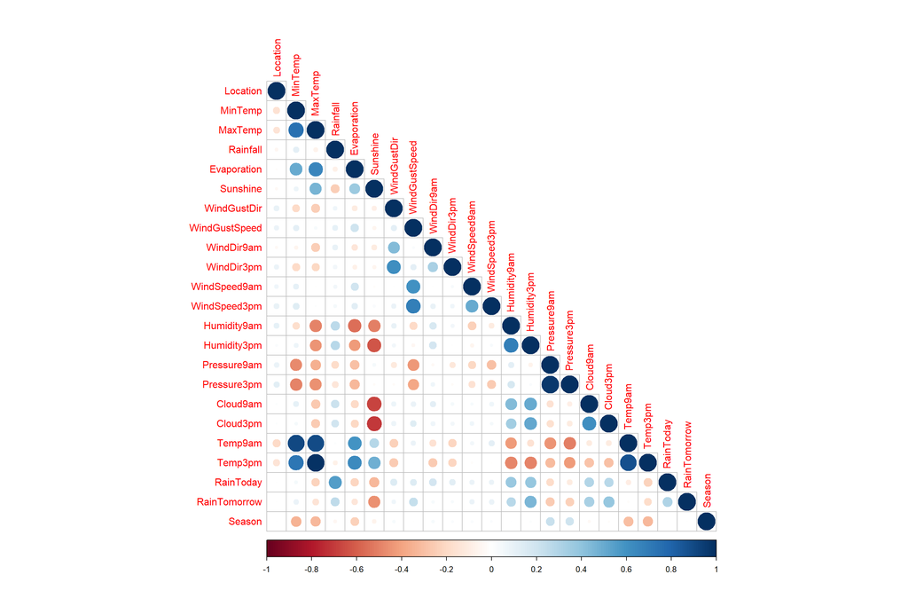

```r
# Mostramos matriz de correlación
corrplot(cor(datos_final), type = 'lower')
```

Eliminamos las columnas Temmp9am y Temp3pm, ya que esta ambas muy correlacionadas con MinTemp y MaxTemp respactivamnete.

```r
# Eliminamos las variables correlacionadas
datos_final <- datos_final %>%
  dplyr::select(-c(Temp9am,Temp3pm))
```

Vamos a comprobar las proporción de nustra variable dependiante, ya que si la variable objetivo está descompensada corremos el riesgo de que el algoritmo de clasificación solamente aprenda sobre la clase de la que tiene más información y en consecunecia genere un modelo que simplemente ignore la clase con menor representación en el juego de datos.

```r
# Representación variable dependiente
counts <- table(datos_final$RainTomorrow)
print(prop.table(counts))
```

```
##
##         0         1
## 0.7797412 0.2202588
```

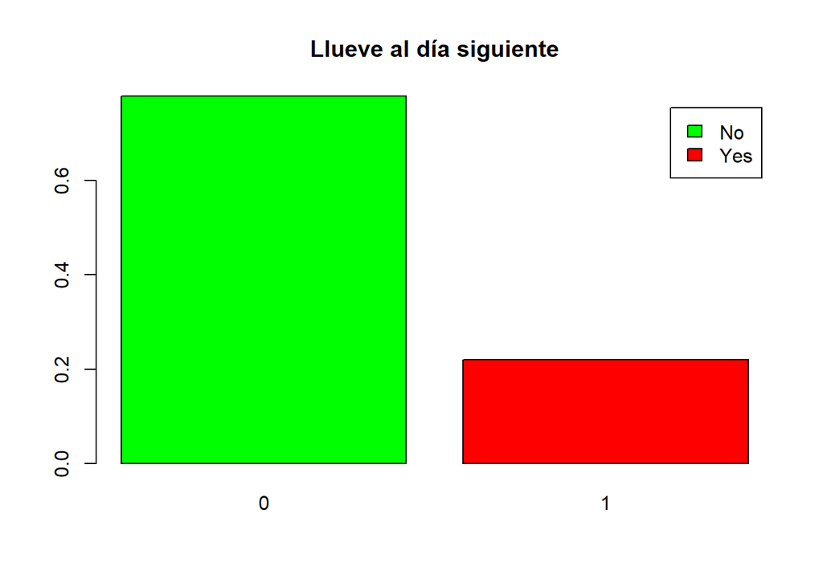

```r
barplot(prop.table(counts),col=c("green","red"),legend=c("No","Yes"), main = "Llueve al día siguiente")
```

Podemos comprobar que el valor 0 (No lleve mañana), representa prácticamente el 78% de los valores, por lo que vamos aplicar el algorimo de oversampling ADSYN el cual solamnete trata de replicar las observaciones de las clases minoritarias con un aprendizadje alto de dificultad por parte del modelo.

```r
# Elegimos una semilla pra que siempre se elija el mismo punto inicial para aplicar el algoritmo ADSYN y PCA.
set.seed(64)
# Variables independientes
x <- c(seq(1,19,1))
# Variable independiente Season
y <- c(seq(21,21))

# Aplicación de ADASYN
datos_oversampled <- ADAS(datos_final[,c(x,y)], datos_final$RainTomorrow, K = 5)$data


# Tranformación a numérico de la nueva variable dependiante surgida del algoritmo ADSYN
datos_oversampled$class <- as.integer(factor(datos_oversampled$class))
```

**PCA**

Aplicamos el análisis de componentes principales al dataset. Empezamos ejecutando la función prcomp().

```r
pca.weather <- prcomp(scale(datos_oversampled))
summary(pca.weather)
```

```
## Importance of components:
##                           PC1    PC2   PC3     PC4     PC5     PC6     PC7
## Standard deviation     2.1557 1.8992 1.554 1.30786 1.10289 1.02010 0.98460
## Proportion of Variance 0.2213 0.1718 0.115 0.08145 0.05792 0.04955 0.04616
## Cumulative Proportion  0.2213 0.3930 0.508 0.58949 0.64741 0.69697 0.74313
##                            PC8     PC9    PC10    PC11    PC12    PC13    PC14
## Standard deviation     0.89629 0.84291 0.80647 0.72423 0.66990 0.64996 0.60753
## Proportion of Variance 0.03825 0.03383 0.03097 0.02498 0.02137 0.02012 0.01758
## Cumulative Proportion  0.78138 0.81522 0.84619 0.87116 0.89253 0.91265 0.93023
##                           PC15    PC16    PC17    PC18    PC19    PC20    PC21
## Standard deviation     0.59013 0.56820 0.51100 0.48858 0.45159 0.26240 0.14674
## Proportion of Variance 0.01658 0.01537 0.01243 0.01137 0.00971 0.00328 0.00103
## Cumulative Proportion  0.94681 0.96218 0.97462 0.98598 0.99570 0.99897 1.00000
```

Como se puede observar la función summary, nos devuelve la proporción de varianza aplicada al conjunto total de cada atributo. Gracias a esto, el atributo 1 explica el 0.2213 de variabilidad del total de datos; en cambio, el atributo 7 explica solo el 0.04616.

A continuación, se muestra un histograma para ver el peso de cada atributo sobre el conjunto total de datos:

```r
# Los valores propios corresponden a la cantidad de variación explicada por cada componente principal (PC).
ev= get_eig(pca.weather)
ev
```

```
##        eigenvalue variance.percent cumulative.variance.percent
## Dim.1  4.64685205       22.1278669                    22.12787
## Dim.2  3.60682260       17.1753457                    39.30321
## Dim.3  2.41512394       11.5005902                    50.80380
## Dim.4  1.71049018        8.1451913                    58.94899
## Dim.5  1.21637630        5.7922681                    64.74126
## Dim.6  1.04061396        4.9553046                    69.69657
## Dim.7  0.96942976        4.6163322                    74.31290
## Dim.8  0.80333154        3.8253883                    78.13829
## Dim.9  0.71049825        3.3833250                    81.52161
## Dim.10 0.65039309        3.0971099                    84.61872
## Dim.11 0.52450522        2.4976439                    87.11637
## Dim.12 0.44876365        2.1369697                    89.25334
## Dim.13 0.42245119        2.0116723                    91.26501
## Dim.14 0.36908879        1.7575657                    93.02257
## Dim.15 0.34825380        1.6583514                    94.68093
## Dim.16 0.32284790        1.5373709                    96.21830
## Dim.17 0.26112062        1.2434315                    97.46173
## Dim.18 0.23871275        1.1367274                    98.59846
## Dim.19 0.20393553        0.9711216                    99.56958
## Dim.20 0.06885573        0.3278844                    99.89746
## Dim.21 0.02153314        0.1025388                   100.00000
```

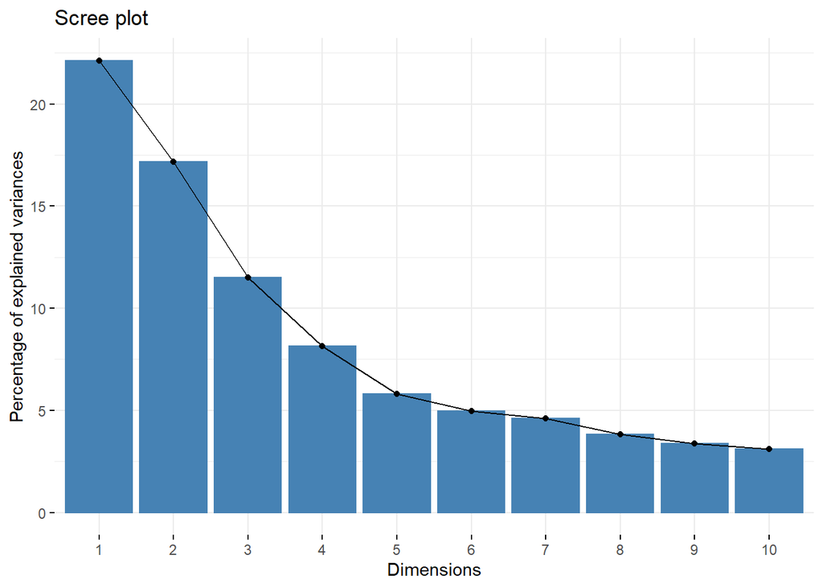

```r
# Mostramos en forma de gráfico la varianza explicada por cada componente principal
fviz_eig(pca.weather)
```

En este proyecto se ha decido utilizar el método de Káiser para decidir cuales de las variables obtenidas serán escogidas. Este criterio mantendrá todas aquellas variables cuya varianza sea superior a 1.

```r
# Comprobamos que variables explican una varianza superior a uno, lo hacemos calculado el cuadrdo de la desviación standar
pca.weather$sdev^2
```

```
##  [1] 4.64685205 3.60682260 2.41512394 1.71049018 1.21637630 1.04061396
##  [7] 0.96942976 0.80333154 0.71049825 0.65039309 0.52450522 0.44876365
## [13] 0.42245119 0.36908879 0.34825380 0.32284790 0.26112062 0.23871275
## [19] 0.20393553 0.06885573 0.02153314
```

Comprobamos que solamnete las 6 primeras componentes tienen tienen una varianza suprior a 1. Tras haber aplicado el métedo de Káiser se han seleccionado las 6 primeras componentes principales.

Los componentes de get_pca_var() se pueden utilizar en el diagrama de variables de la siguiente manera:

```r
var <- get_pca_var(pca.weather)
var
```

```
## Principal Component Analysis Results for variables
##  ===================================================
##   Name       Description
## 1 "$coord"   "Coordinates for the variables"
## 2 "$cor"     "Correlations between variables and dimensions"
## 3 "$cos2"    "Cos2 for the variables"
## 4 "$contrib" "contributions of the variables"
```

- var$coord: coordenadas de variables para crear un diagrama de dispersión.
- var$cos2: representa la calidad de representación de las variables al mapa de factores. Se calcula como las coordenadas al cuadrado: var.cos2 = var.coord * var.coord.
- var$contrib: contiene las contribuciones (en porcentaje) de las variables a los componentes principales. La contribución de una variable (var) a un determinado componente principal es (en porcentaje): (var.cos2 * 100) / (cos2 total del componente).

**Coordenadas de la variables**

```r
# Empleamos solamnente las 6 primeras componente principales
head(var$coord[,1:6],11)
```

```
##                     Dim.1       Dim.2       Dim.3       Dim.4         Dim.5
## Location      -0.11653215  0.09300839 -0.25702263  0.18944970 -0.1065233599
## MinTemp        0.33960907 -0.60975583  0.46643305 -0.16569726  0.0474206727
## MaxTemp        0.73613570 -0.37512099  0.36803490 -0.17698875 -0.0008540048
## Rainfall      -0.33612997 -0.30141424  0.09430306 -0.22806472  0.6553628109
## Evaporation    0.66887957 -0.38143968  0.05140860 -0.05766429 -0.0766243087
## Sunshine       0.78239431  0.20625732 -0.20230845 -0.20163708  0.2279745242
## WindGustDir   -0.28163357 -0.06179660 -0.57223463 -0.55121082 -0.2343809584
## WindGustSpeed  0.04519730 -0.63091338 -0.55010078  0.33517416  0.0689340871
## WindDir9am    -0.31507426 -0.02373387 -0.35147393 -0.50606040  0.0077616674
## WindDir3pm    -0.23869277 -0.04521076 -0.56860307 -0.52933149 -0.2207038660
## WindSpeed9am   0.07202843 -0.43544265 -0.49582874  0.44595164  0.1688552661
##                      Dim.6
## Location       0.636423406
## MinTemp        0.186927881
## MaxTemp        0.097272082
## Rainfall       0.010727543
## Evaporation    0.237182680
## Sunshine      -0.027574209
## WindGustDir    0.047737975
## WindGustSpeed  0.001863683
## WindDir9am     0.084507495
## WindDir3pm     0.040680974
## WindSpeed9am   0.109253029
```

**Calidad de representación**

La calidad de representación de las variables en el mapa de factores se denomina cos2 (coseno cuadrado, coordenadas cuadradas). Podemos acceder al cos2 de la siguiente manera:

```r
# Valores calidad de representación de cada variable en las PCs
head(var$cos2[,1:6],11)
```

```
##                     Dim.1        Dim.2       Dim.3      Dim.4        Dim.5
## Location      0.013579742 0.0086505608 0.066060630 0.03589119 1.134723e-02
## MinTemp       0.115334320 0.3718021683 0.217559788 0.02745558 2.248720e-03
## MaxTemp       0.541895762 0.1407157535 0.135449688 0.03132502 7.293242e-07
## Rainfall      0.112983356 0.0908505454 0.008893067 0.05201352 4.295004e-01
## Evaporation   0.447399882 0.1454962329 0.002642844 0.00332517 5.871285e-03
## Sunshine      0.612140858 0.0425420819 0.040928709 0.04065751 5.197238e-02
## WindGustDir   0.079317468 0.0038188196 0.327452472 0.30383337 5.493443e-02
## WindGustSpeed 0.002042795 0.3980516876 0.302610868 0.11234172 4.751908e-03
## WindDir9am    0.099271790 0.0005632968 0.123533922 0.25609713 6.024348e-05
## WindDir3pm    0.056974240 0.0020440130 0.323309453 0.28019183 4.871020e-02
## WindSpeed9am  0.005188095 0.1896103044 0.245846140 0.19887286 2.851210e-02
##                      Dim.6
## Location      4.050348e-01
## MinTemp       3.494203e-02
## MaxTemp       9.461858e-03
## Rainfall      1.150802e-04
## Evaporation   5.625562e-02
## Sunshine      7.603370e-04
## WindGustDir   2.278914e-03
## WindGustSpeed 3.473314e-06
## WindDir9am    7.141517e-03
## WindDir3pm    1.654942e-03
## WindSpeed9am  1.193622e-02
```

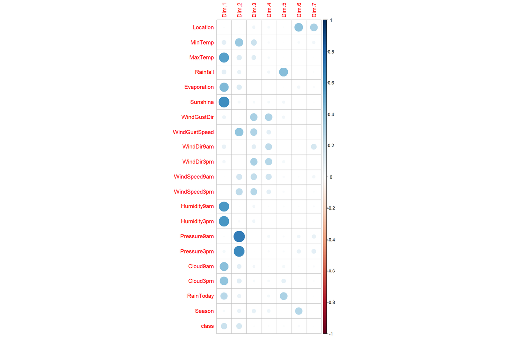

```r
# Mostramos los resulatdos de las representación
corrplot(var$cos2[,1:7], is.corre=FALSE)
```

- Un cos2 elevado indica una buena representación de la variable en el componente principal. En este caso, la variable se coloca cerca de la circunferencia del círculo de correlación.
- Un cos2 bajo indica que la variable no está perfectamente representada por los PC. En este caso, la variable está cerca del centro del círculo.

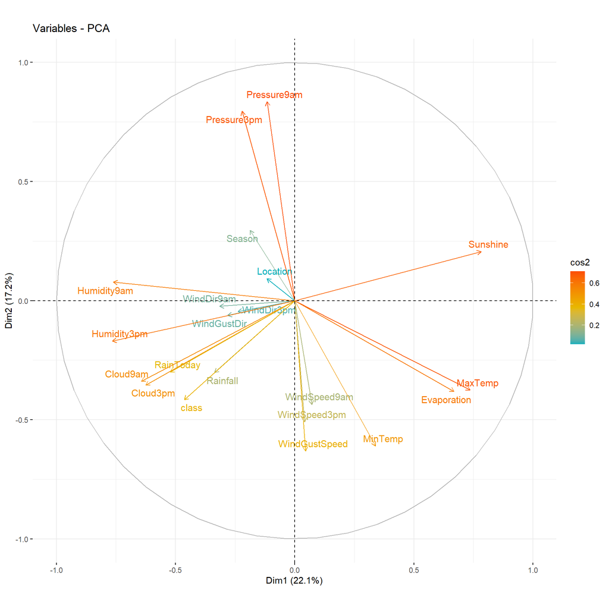

```r
fviz_pca_var(pca.weather,
col.var = "cos2",
gradient.cols = c("#00AFBB", "#E7B800", "#FC4E07"),
repel = TRUE
)
```

Interpretando los gráficos y la información previamemte explciada podemos llegar a la conclusión que las variables mejor representadas en las PC1 son MaxTemp, Evaporation, Sunshine, Humidity9am y Humidity3pm mientras que las mejor repsentadas en las PC2 son Pressure9am y Pressure3pm.

**Contribución**

Las contribuciones de las variables en la contabilización de la variabilidad de un determinado componente principal se expresan en porcentaje.

Las variables que están correlacionadas con PC1 (es decir, Dim.1) y PC2 (es decir, Dim.2) son las más importantes para explicar la variabilidad en el conjunto de datos.

Las variables que no están correlacionadas con ningún PC o con las últimas dimensiones son variables con una contribución baja y se pueden eliminar para simplificar el análisis global.

La contribución de las variables se puede extraer de la siguiente manera:

```r
head(var$contrib[,1:7],11)
```

```
##                     Dim.1       Dim.2      Dim.3      Dim.4        Dim.5
## Location       0.29223530  0.23983882  2.7352894  2.0982985 9.328714e-01
## MinTemp        2.48198821 10.30830207  9.0082246  1.6051295 1.848704e-01
## MaxTemp       11.66156693  3.90137717  5.6083949  1.8313473 5.995877e-05
## Rainfall       2.43139559  2.51885262  0.3682240  3.0408544 3.530983e+01
## Evaporation    9.62802080  4.03391709  0.1094289  0.1943987 4.826865e-01
## Sunshine      13.17323753  1.17948917  1.6946836  2.3769509 4.272722e+00
## WindGustDir    1.70690754  0.10587767 13.5584127 17.7629413 4.516237e+00
## WindGustSpeed  0.04396085 11.03607613 12.5298277  6.5678084 3.906610e-01
## WindDir9am     2.13632344  0.01561754  5.1150138 14.9721485 4.952701e-03
## WindDir3pm     1.22608250  0.05667074 13.3868679 16.3807912 4.004533e+00
## WindSpeed9am   0.11164751  5.25699003 10.1794420 11.6266590 2.344020e+00
##                      Dim.6        Dim.7
## Location      3.892267e+01 33.702774708
## MinTemp       3.357829e+00  5.945872691
## MaxTemp       9.092573e-01  0.495492537
## Rainfall      1.105887e-02  1.159792305
## Evaporation   5.406003e+00  2.498480485
## Sunshine      7.306619e-02  0.790577142
## WindGustDir   2.189971e-01  0.003233609
## WindGustSpeed 3.337754e-04  0.001125987
## WindDir9am    6.862792e-01 18.459866398
## WindDir3pm    1.590351e-01  0.085332379
## WindSpeed9am  1.147037e+00  6.031211258
```

Cuando más grande sea el valor de la contribución, más contribución habrá al componente.

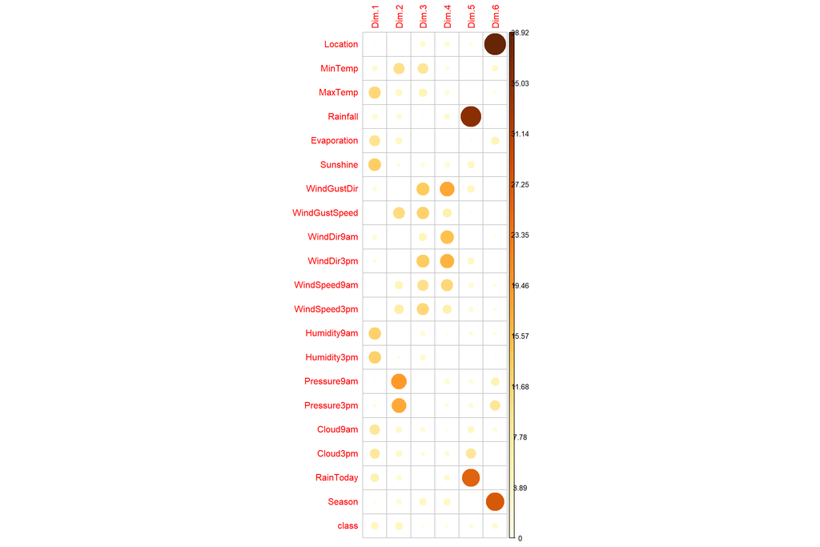

```r
corrplot(var$contrib[,1:6], is.cor=FALSE)
```

Las variables más importantes (que más contribuyen) se pueden resaltar a la gráfica de correlación de la siguiente manera:

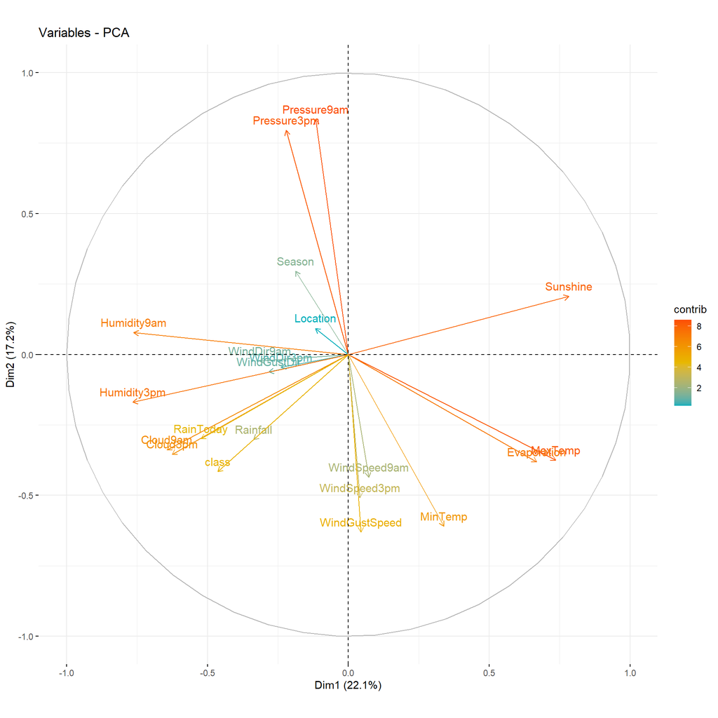

```r
fviz_pca_var(pca.weather, col.var = "contrib",
gradient.cols = c("#00AFBB", "#E7B800", "#FC4E07")
)
```

Las variables correlacionadas positivas apuntan al mismo lado de la trama. Las variables correlacionadas negativas tienen la misma dirección pero sentidos opuestos en gráfico. Por ejemplo, vemos que la insolacion (Sunshine) y la Humedad (Humidity3pm) apuntan en sentido opuesto por tanto tienen una correlación negativa, además lo hemos visto antes cuando hemos el anális de las relaciones entre las variables. Las variables correlacionads positivamente tienen la misma dirección y sentido, como por ejemplo, vemos que la evaporavión (Evaporation) y la temperatura máxima (MaxTemp) tienen la misma dirección y sentido.

Si nos centramos en nuestra varible dependiente RainTomorrow ahora denominada class, comprobamos que aporta a la PC1. Basándonos en la explicación anterior y solamnete eligiendo variables con una aportación destacable en la PC1, podemos ver que la varibles que tienen una correlación positiva con ella (una dirección y sentido similar) son, Cloud9am, Cloud3pm y Humidity3pm y una correlación negativa (una dirección similar pero un sentido opuesto) la insolación (Sunshine).

De tal manera que podríamos que un buen indicador de que sí que va a llover al día siguiente sería valores altos para la fracción del cielo tapado por nubes a las 9 de la mañana (Cloud9am), a las 3 de tarde (Cloud3p) y la humedad a las 3 de la tarde (Humidity3pm) y valores bajos en la insolación (Sunshine) del día anterior

**CONCLUSIONES**

Los datos estudiados contemplan características del tiempo atmosférico en Australia ,desde 2007 hasta 2018, como la humedad, la temperatura, la presión atmosférica, la dirección y velocidad del viento, la localización, la cantidad de lluvia, la cantida de cielo tapado por nubes y la evaporación.

Tras haber revisado los datos, estos paracen bien informados pero algunas de sus variables presentan cerca del 50% de valores nulos, por lo que se ha optado por la eliminación de estos para evitar el posible caso de overfitting.

Hemos observado que la temperatura media a las 9 de la mañana de unos 18 grados celsius y a las 3 de la tarde de unos 22 grados celsius. Con t.test() hemos comprobado que la temperatura media entre los dos grupos de nuestra variable dependiente (Sí o No) son significativamente diferentes, con lo que la temperatura podría influir en el si lloverá o no al dia siguiente, pero necesitaría de un estudio en profundidad.

Lo mismo nos ha pasado con los datos de las variable Rainfall, Sunshine y windSpeed9am, donde con el t.test() hemos obtenido un resultado de media significativamnete diferente entre cada uno de los grupos de nuestra variable dependiente RainTomorrow. Por lo que lluvía, la insolación y la dirección del viento podria influir en la lluvia, pero pensamos que sería necesario un estudio en mayor profundiad.

También hemos comprobado que no hay ninguna dirección de viento predomienante sinó que todas tienen una presencia similar, pero que existe una relación de dependencia entre la dirección del viento y si llueve al día siguiente, pero sería necesario un estudio en mayor profundiad.

Tras haber hecho un análisis exploratorio de los datos, hemos extraido una serie de relaciones. Existe una correlación positiva entra la temperatura máxima y evaporación, entre la insolación y la temperatura a las 3 de la tarde. Hemos observado una correlación negativa entre la lluvía y la evaporación, la cual necesitaría un posterior estudio, entre la temperatura mínima y la humedad y entre la insolación y la humedad.

Finalmente, hemos aplicado la técnica de componente principales y hemos concluido que un buen indicador de si va a llover al día siguiente sería unos valores altos para la fracción del cielo tapado por nubes a las 9 de la mañana, a las 3 de tarde y la humedad a las 3 de la tarde y valores bajos para la insolación del día anterior.

## Creación de modelos

Tal y como dijimos en este proyecto se ha decido utilizar el método de Káiser para decidir cuales de las variables obtenidas serán escogidas. Este criterio mantendrá todas aquellas variables cuya varianza sea superior a 1. Tras haber aplicado el métedo de Káiser se han seleccionado las 6 primeras componentes principales.

```r
# Cargamos los datos transformados
data <- read.csv('weatherAUS_1.csv')
head(data)
```

```
##          PC1        PC2        PC3       PC4        PC5         PC6 class
## 1  1.5975299 -2.0378790  0.9025034 0.3633921 -1.4991296  0.61789856     2
## 2 -1.1649610 -0.5292786  1.9945580 0.5122580 -1.8538881  0.24002991     2
## 3 -1.2392748  0.1305746  1.7770138 0.3319415 -1.0458780  0.49520374     2
## 4 -3.0461991 -1.5559117  1.9619602 1.8535692  1.2135671  1.21790114     2
## 5 -0.8816979 -0.7173087 -2.2504896 4.7683572  0.6050712  0.03810966     2
## 6  0.9841049 -1.2848168  1.8567925 0.3665261  1.7903192 -1.97181468     2
```

Dimensiones dataframe

```r
dim(data)
```

```
## [1] 85594     7
```

Vemos que tenemos **7** variables y **85594** registros.

6 para las PCs seleccionadas y 1 para la variable dependiente.

Al tener bastantes registros, cuando aplicamos los algoritmos, tardan mucho tiempo al ejecutarse. Por lo que hemos decidido, seleccionar el 20% de los regitros para pooder aplicar los algoritmos ágilmente, ya que seguimos cumpliendo con el mínimo de 500 regstros pedido en la PR1. Aunque, perdamos información, como la idea de la práctica es mostrar el aprendizaje adquirido sobre la asignatura, a la hora de aplicar modelos, y no conseguir los mejores resultados, pensamos que no afectará en el desarrollo de la práctica.

```r
# Denomtamos la semilla, para seleccionar siempre el mismo subset de registros
set.seed(24)

# Seleccionamos el 20% del dataset original
data_sample <- data %>%
  sample_frac(0.2)

# comprobamos que la variiable dependiente no se ha desbalanceado
counts <- table(data_sample$class)
print(prop.table(counts))
```

```
##
##         1         2
## 0.5048776 0.4951224
```

Tenemos uns 50.5% de una categoria y un 49.5% de la otra por lo que no hemos sufrido ningún desbalanceamiento con la variable dependiente.

1. Aplicar un modelo **no supervisado** y basado en el concepto de distancia, sobre el juego de datos.

Eliminamos nuestra variable dependiente del dataframe, para aplicar los métodos no supervisados

```r
unsupervised_data <- data_sample %>%
  dplyr::select(-class)
```

Vamos a emplear un algoritmo de agrupación jerárquica de tipo aglomerativo, es decir, partiendo de una fragmentación completa de los datos, estos se van fusionando hasta conseguir una situación contraria, es decir, todos los datos se unen en un solo grupo.

Para realizar este método es muy importante escalar los valores de las variables, ya que la clasificación de los datos en un grupo u otro se hace midiendo las distancias entre ellos. Por tanto, si cada columna está en una escala diferente el método no obtendría el resultado correcto. Sin embargo, como empleamos los resulatdos del PCA que ya estan escalados no hará falta escalarlos otra vez.

Primero de todo computamos la matriz de distancia Euclidiana, para tener la distancia entre los puntos.

Calculamos las matriz con la distancia euclidiana entre los registros

```r
# Calculamos da distancia euclidiana, ya que empleamos loo datos escalado, ya que provienen del PCA
dist_mat <- cluster::daisy(unsupervised_data, metric = "euclidean")
```

En este caso empleamos el Enlace completo o complete linkage, donde tomaremos como criterio la distancia máxima entre los elementos del grupo.

```r
# Aplicamos el algoritmo
hc_complete <- hclust(dist_mat, method = 'complete')
```

Como sabemos que tenemos dos grupos en nuestra variable dependiente vamos a dividir el dendograama en dos clústers

```r
hc_complete_cut <- cutree(hc_complete, 2)
```

Mostramos el dendograma dividido para dos grupos

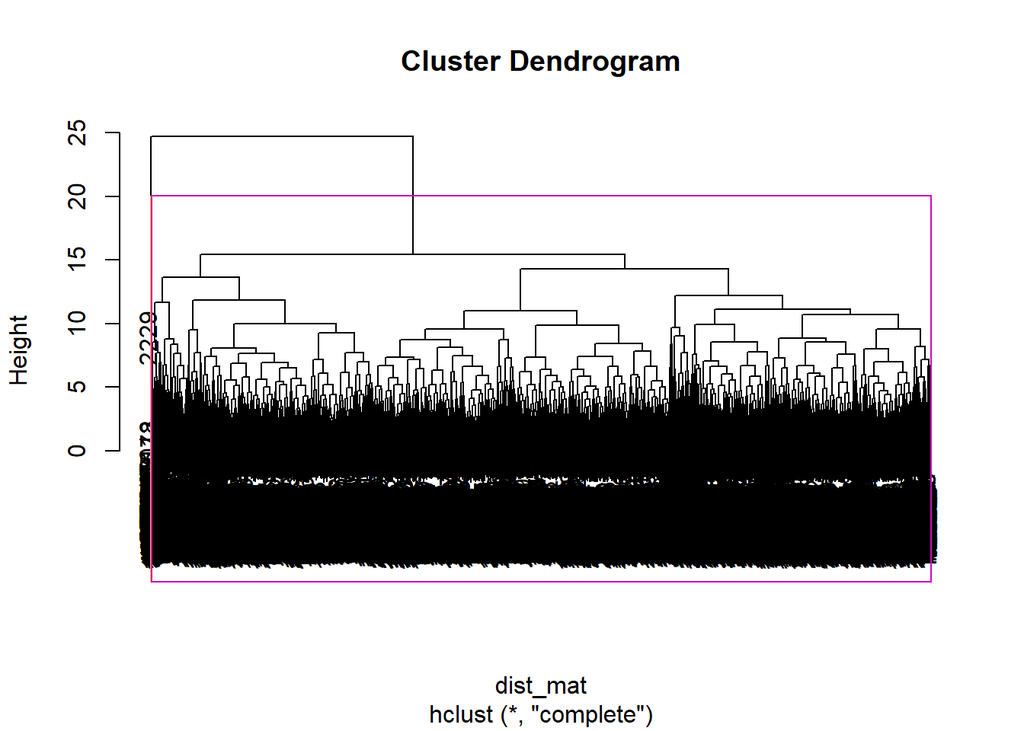

```r
plot(hc_complete)
rect.hclust(hc_complete, k = 2, border=7:6)
```

Viendo el dendograma ya podemos intuir quee los resultados no serán buenos, ya que da la sensación de solamnente ha sido capaz de difereniciar un grupo.

Vamos a comprobarlo, para ello:

Comparamos con los datos originales:

```r
table(hc_complete_cut, data_sample$class)
```

```
##
## hc_complete_cut    1    2
##               1 8638 8460
##               2    5   16
```

Mostramos los resultados en porcentaje, obtenemos:

```r
prop.table(table(hc_complete_cut, data_sample$class))
```

```
##
## hc_complete_cut            1            2
##               1 0.5045855482 0.4941877446
##               2 0.0002920731 0.0009346340
```

2. Aplicar de nuevo el modelo anterior, pero usando una **métrica de distancia diferente** y comparar los resultados.

Vamos aplicar el mismo algorimto que en apartado anterior, pero en este caso empleamos el Enlace medio o average linkage, donde tomaremos como criterio la distancia media entre los elementos del grupo

```r
# Aplicamos el algoritmo
hc_average <- hclust(dist_mat, method = 'average')
```

Como sabemos que tenemos grupos en nustra variable dependiente vamos a dividir el dendograama en dos clústers

```r
hc_average_cut <- cutree(hc_average, 2)
```

Mostramos el dendograma dividido para dos grupos

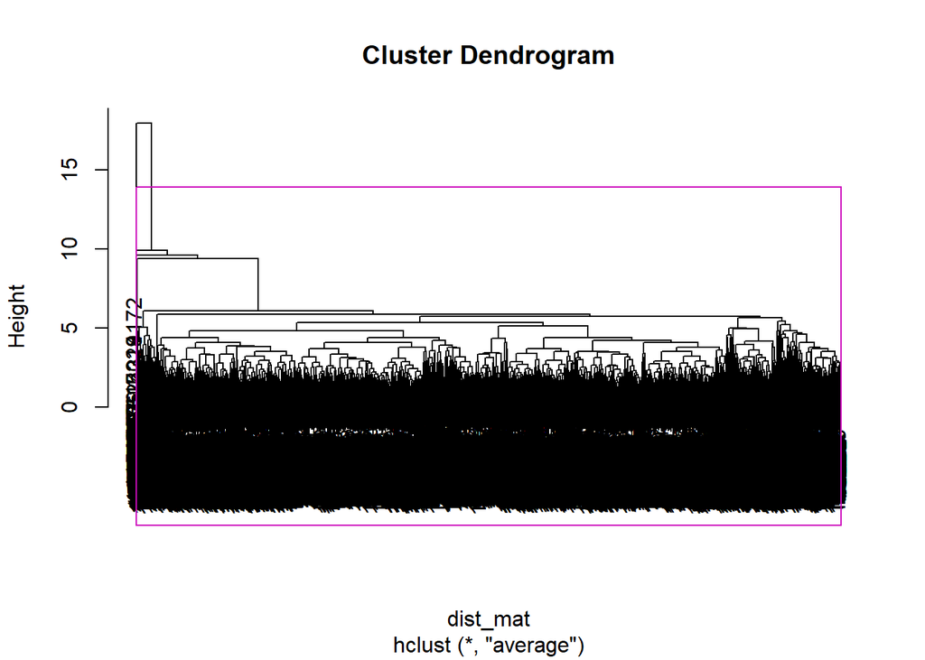

```r
plot(hc_average)
rect.hclust(hc_average, k = 2, border=7:6)
```

Viendo el dendograma ya podemos intuir quee los resultados no serán buenos, ya que da la sensación de solamnente ha sido capaz de difereniciar un grupo.

Vamos a comprobarlo, para ello:

Comparamos con los datos originales:

```r
table(hc_average_cut, data_sample$class)
```

```
##
## hc_average_cut    1    2
##              1 8642 8475
##              2    1    1
```

Mostramos los resultados en porcentaje, obtenemos:

```r
prop.table(table(hc_average_cut, data_sample$class))
```

```
##
## hc_average_cut            1            2
##              1 5.048192e-01 4.950640e-01
##              2 5.841463e-05 5.841463e-05
```

Igual que en el apartado anterior nos damos cuenta que a pesar de haber cambiado la métrica de distancia los resultados son muy similares. No ha sido capaz de descubrir que nuestros datos tenian dos grupos diferenciados, ya que como clase 2, solamente hay clasificados dos registros y uno de ellos incorrectamnete.

Como ha clasificado a todos los registros como 1, de la categoría 1 ha clasificado correctamente el 50.4% y de la clase 2 el 0% aproximadamente, por lo que los resultados son prácticamente iguales a los del apartado anterior. Ambos se asemejan al azar.

Comprobamos que en ambos casos no se ha sido capaz de identificar que hay dos grupos de datos. Solamente se ha identifacado un grupo, de tal manera que ambos resultados son muy similares. Aunque vemos que el resultado es un poco mejor para el algoritmo que hemos emleado el enlace completo, las diferencias entre los resultados no paracen significativas, ya que en ambos casos, de la clase dos se han acertado paracticamnete el 0% de los registros.

Como conclusión podemos extraer, que para este dataset, debemos de buscar otro tipo de algoritmo que no se el jerárquico aglomerativo, ya que con este obtenemos muy malos resultados.

3. Se aplican lo algoritmos **DBSCAN y OPTICS**, se prueban con diferentes valores de eps y se comparan los resultados con los métodos anteriores.

```r
# Creamos el vector que contendrá los resultados del índice silhouette
sil_DBSCAN <- rep(0,50)
```

Iteramos y probamos diferente valores de eps. Asimismo, vamos a graficar y mostrar los grupos que hemos conseguido para cada valor de eps, su valor obtenido para el índice silhouette y la proporción de datos clasificados correctamente.

```
## eps 5
```

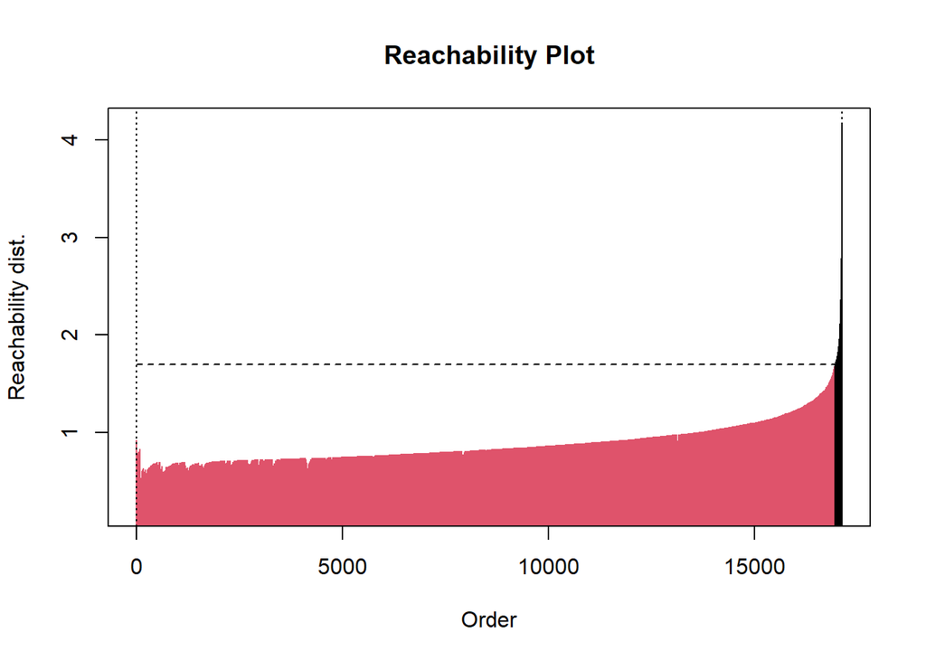

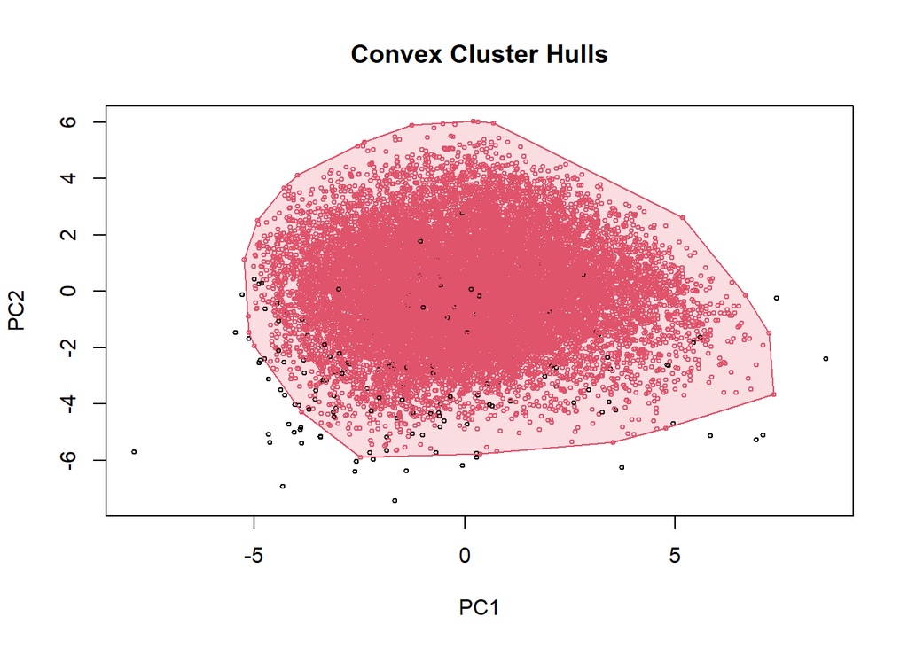

```
## Con el valor 5 el valor de silhouette es 0.34
## Con el valor 5 de eps hemos clasificados correctamnete 50.66 %
```

```
## eps 10
```

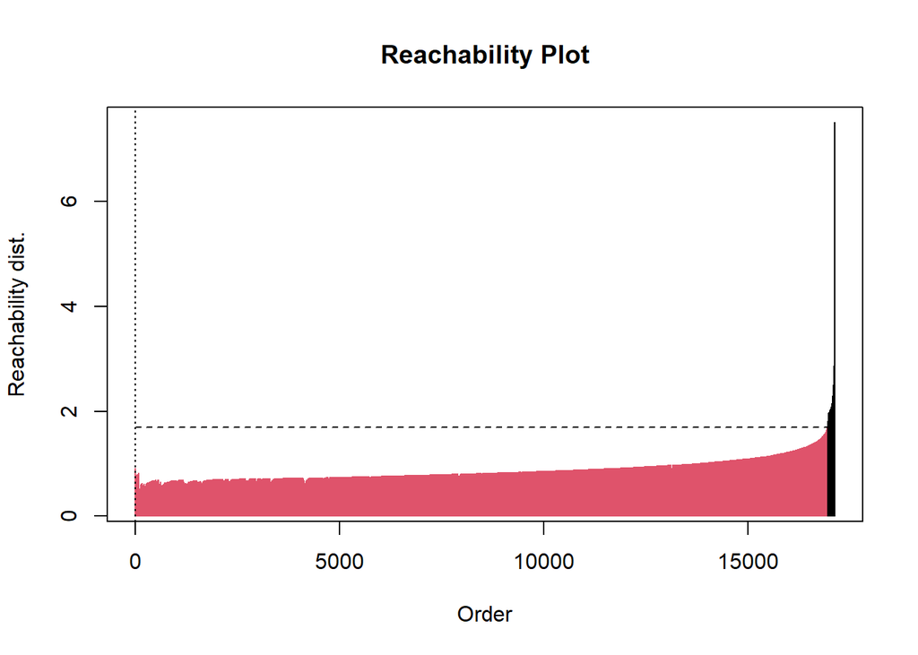

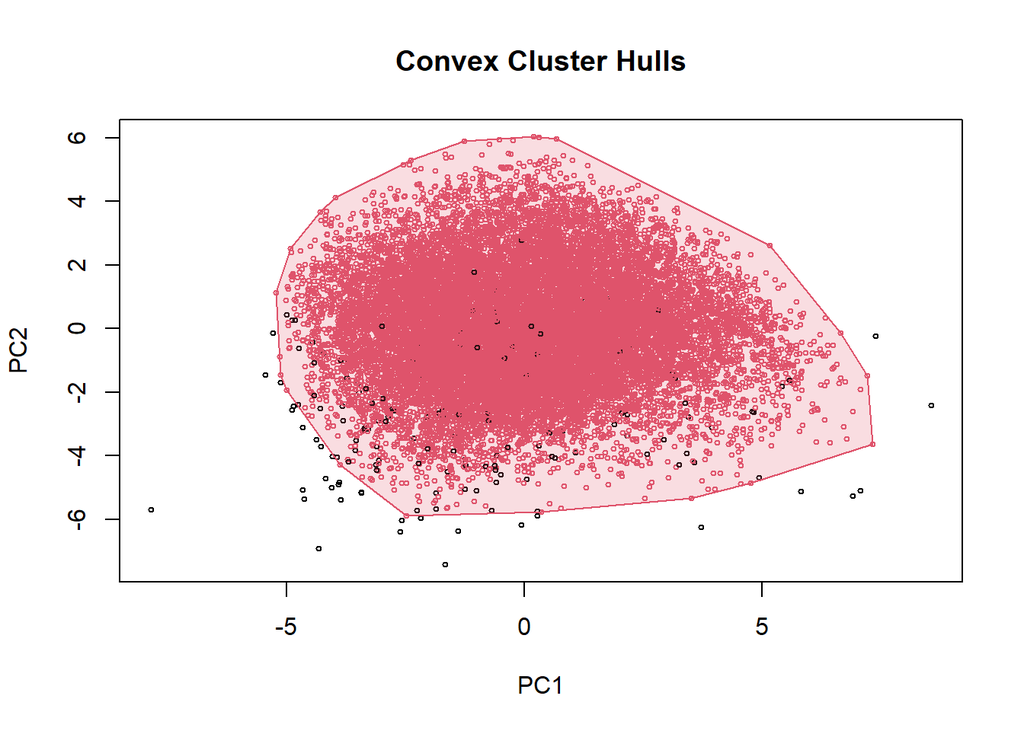

```
## Con el valor 10 el valor de silhouette es 0.34
## Con el valor 10 de eps hemos clasificados correctamnete 50.66 %
```

```
## eps 15
```

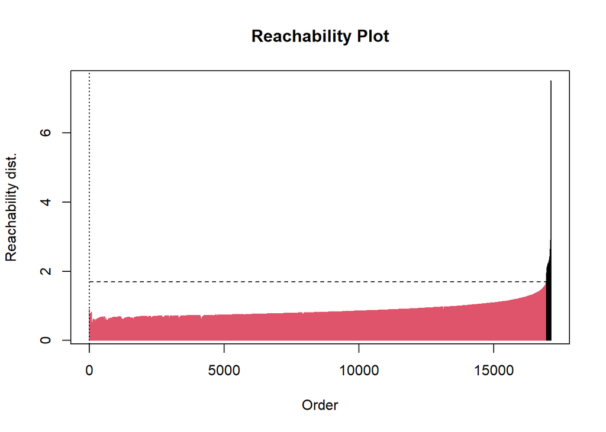

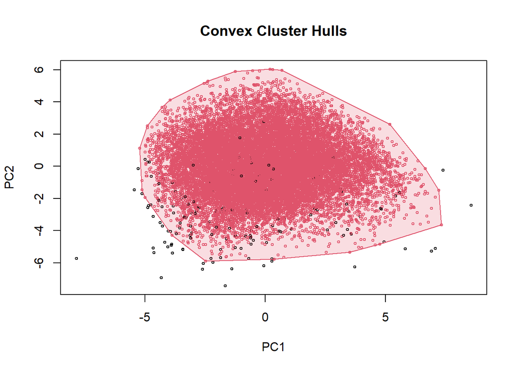

```
## Con el valor 15 el valor de silhouette es 0.34
## Con el valor 15 de eps hemos clasificados correctamnete 50.66 %
```

```
## eps 20
```

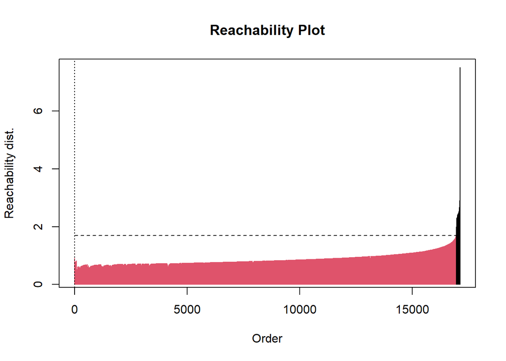

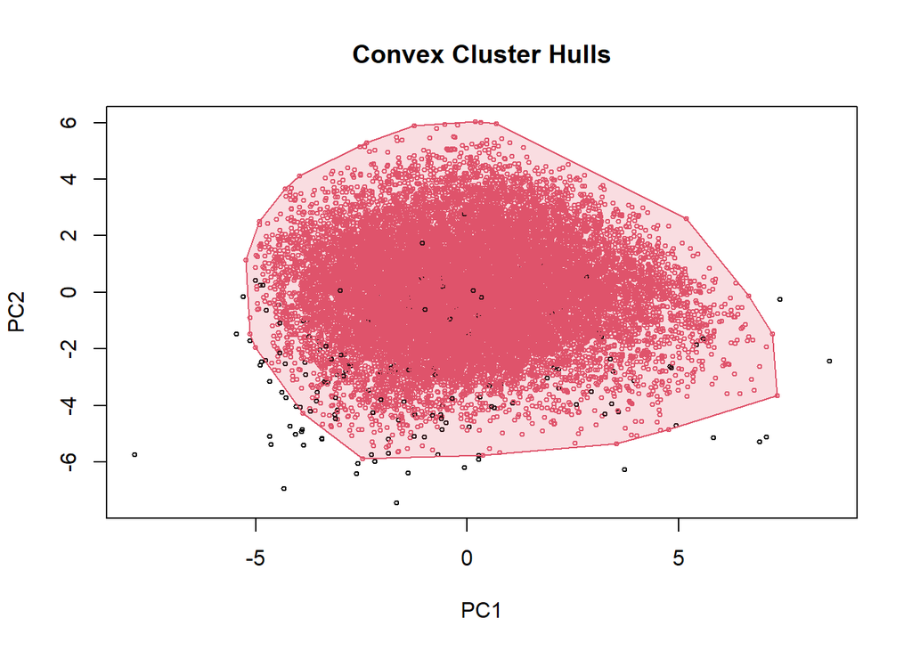

```
## Con el valor 20 el valor de silhouette es 0.34
## Con el valor 20 de eps hemos clasificados correctamnete 50.66 %
```

```r
# Probamos diferentes valores de eps
for (i in seq(5,20,5)) {

  # Con minPts indicamos los puntos vecinos y con eps la distancia máxima que debe estar el punto para introducirlo en el cluster
  res <- optics(unsupervised_data, minPts= 5, eps = i)

  # En este caso determinamo que aquellos puntos que estén a mas de 2 de distancia los denominamos outliers
  res1 <- extractDBSCAN(res, eps_cl = 1.7)

  cat(paste(c('eps', i)))

  # Mostramos el reachability plot
  plot(res1)

  # Mostramos las areas creadas para cada especie
  hullplot(unsupervised_data, res1)

  # Calculamos el valor silhouette para cada valor de eps y lo añadimos a los resultados
  y_cluster <- res1$cluster
  sk <- silhouette(y_cluster, dist_mat)
  sil_DBSCAN[i] <- mean(sk[,3])

  cat(paste('Con el valor', i, 'el valor de silhouette es', round(mean(sk[,3]), digits = 2), '\n'))

  # Creamos una columna para cada resultado de eps
  unsupervised_data[,paste('DBSCAN',i, sep="_")] <-  res1$cluster

  # Utilizamos la exactitud(correctas/total), como medida de los bueno que es el agrupamiento, multilpicando por 100 obtenemos el porcentaje de registros clasificados de manera correcta, eliminaos los registros que ha detectado como outliers [res1$cluster != 0]
  correctas <- mean(data_sample$class[res1$cluster != 0] == res1$cluster[res1$cluster != 0])

  cat(paste(c('Con el valor', i, 'de eps hemos clasificados correctamnete', round(correctas*100, digits = 2), '%')))

  # Mostramos la clasificación del algoritmo DBSCAN
  plot(unsupervised_data[c(1,2)], col=res1$cluster, main="DBSCAN")

  # Mostramos la valores reales
  plot(unsupervised_data[c(1,2)], col=as.factor(data_sample$class), main="Clasificación real")
}
```

[output not shown]

Un paso muy interesante del algoritmo es la generación de un diagrama de alcanzabilidad o reachability plot, en el que se aprecia de una forma visual la distancia de alcanzabilidad de cada punto. En estos, Los valles representan clusters (cuanto más profundo es el valle, más denso es el cluster), mientras que las cimas indican los puntos que están entre las agrupaciones (estos puntos son cadidatos a ser considerardos outliers). Si observamos los diagrams de alcanzabiliad nos damos cuenta que no tenemos valles y cimas sino que solamente observamos un valle, así que el algoritmo solamnete es capaz de diferenciar un grupo.

Si nos centramos en el porcentaje de registrso clasificados correctamnete, vemos que todos los valores de eps, obtienen el mismo resultado 50.66%. También aplicamos el método Silhouette, el cual proporciona un valor entre -1.0 y 1.0 que indica lo bien o mal que está agrupado dicho punto en su grupo. Los valores cercanos a 1.0 indican que la muestra está en el grupo correcto. Los valores cercanos a –1.0 indican que la muestra está en el grupo incorrecto. Por tanto, cuanto mayor es el valor, mejor agrupados están los datos. Observamos que todos los valores eps obtienen un silhouette = 0.34, un valor bastante bajo, de tal manera que podemos concluir que no están bien agrupados. Así que, teniendo en consideración estos datos podemos intuir que el algoritmo no ha funcionado de una manera correcta para este grupo de datos.

En referencia a los tres apartados, vemos que los resulatados son malos y muy similares en todos los casos tanto con los métodos aglomerativos como con DBSCAN y OPTICS. De tal manera que, aunque el resultado de DBSACN es algo mejor, 50.66% frente al 50.4% del método aglomerativo, por lo malos y similares resultados obtenidos por los tres métodos aplicados no podemos conluir que alguno de ellos tenga un mejor comportanmineto con respesto a los demás.

Como conlcusión podríamos comentar que, como con todos los modelos modelos hemos obtenidos malos resultados y similares, es posible que debamos buscar algún algoritmo diferente a estos modelos insupervisados basados en la distancia, para ver si su mejoran los resultados.

4. Aplicar un modelo de generación de reglas a partir de **árboles de decisión** ajustando las diferentes opciones de creación como sin y con opciones de poda o boosting y comparar los resultados.

```r
data_sample$class <- ifelse(data_sample$class == 1, 'No', 'Yes')
```

PREPARACIÓN DE LOS DATOS PARA EL MODELO

Para la futura evaluación del árbol de decisión, es necesario dividir el conjunto de datos en un conjunto de entrenamiento y un conjunto de prueba. El conjunto de entrenamiento es el subconjunto del conjunto original de datos utilizado para construir un primer modelo; y el conjunto de prueba, el subconjunto del conjunto original de datos utilizado para evaluar la calidad del modelo.

Lo más correcto será utilizar un conjunto de datos diferente del que utilizamos para construir el árbol, es decir, un conjunto diferente del de entrenamiento. No hay ninguna proporción fijada con respecto al número relativo de componentes de cada subconjunto, pero la más utilizada acostumbra a ser 2/3 para el conjunto de entrenamiento y 1/3, para el conjunto de prueba.

De esta forma, tendremos un conjunto de datos para el entrenamiento y uno para la validación.

```r
set.seed(666)
# Variables independientes
X <- data_sample[,1:6]
# Variable dependientes
y <- data_sample[,7]
```

De forma dinámica podemos definir una forma de separar los datos en función de un parámetro, en este caso del “split_prop”. Podemos crear un rango utilizando “split_prop”.

```r
split_prop <- 3
indexes = sample(1:nrow(data_sample), size=floor(((split_prop-1)/split_prop)*nrow(data_sample)))

# Datos entrenamaniemto del modelo
trainX<-X[indexes,]
trainy<-y[indexes]

# Datos evaluación del modelo
testX<-X[-indexes,]
testy<-y[-indexes]
```

Después de una extracción aleatoria de casos es altamente recomendable efectuar un análisis de datos mínimo para asegurarnos de no obtener clasificadores sesgados por los valores que contiene cada muestra. En este caso, verificaremos que la proporciónde clases es constante en los dos conjuntos:

```r
summary(trainX);summary(trainy);table(trainy)
```

```
##       PC1                PC2                PC3                 PC4
##  Min.   :-5.52419   Min.   :-7.47248   Min.   :-6.174492   Min.   :-4.677836
##  1st Qu.:-1.59820   1st Qu.:-1.30899   1st Qu.:-1.000062   1st Qu.:-0.911769
##  Median :-0.05626   Median :-0.01040   Median : 0.060760   Median :-0.087275
##  Mean   : 0.01386   Mean   : 0.02474   Mean   : 0.008141   Mean   :-0.008152
##  3rd Qu.: 1.52267   3rd Qu.: 1.33891   3rd Qu.: 1.088631   3rd Qu.: 0.855501
##  Max.   : 7.40294   Max.   : 5.99404   Max.   : 4.650735   Max.   : 6.038185
##       PC5                PC6
##  Min.   :-2.90453   Min.   :-4.25152
##  1st Qu.:-0.75096   1st Qu.:-0.70530
##  Median :-0.07330   Median :-0.03950
##  Mean   :-0.01054   Mean   :-0.01005
##  3rd Qu.: 0.63203   3rd Qu.: 0.71356
##  Max.   : 9.66944   Max.   : 3.45302
```

```
##    Length     Class      Mode
##     11412 character character
```

```
## trainy
##   No  Yes
## 5776 5636
```

```r
summary(testX);summary(testy);table(testy)
```

```
##       PC1                PC2                 PC3                PC4
##  Min.   :-8.11252   Min.   :-6.432784   Min.   :-6.74830   Min.   :-4.96253
##  1st Qu.:-1.61297   1st Qu.:-1.323885   1st Qu.:-1.00398   1st Qu.:-0.90084
##  Median :-0.08336   Median :-0.034401   Median : 0.04292   Median :-0.11002
##  Mean   : 0.01343   Mean   :-0.007072   Mean   :-0.00033   Mean   :-0.02408
##  3rd Qu.: 1.53763   3rd Qu.: 1.296367   3rd Qu.: 1.07722   3rd Qu.: 0.82647
##  Max.   : 8.50301   Max.   : 6.003869   Max.   : 5.04355   Max.   : 4.89387
##       PC5                PC6
##  Min.   :-2.75524   Min.   :-3.44158
##  1st Qu.:-0.76274   1st Qu.:-0.71070
##  Median :-0.10689   Median :-0.04475
##  Mean   :-0.02756   Mean   :-0.01332
##  3rd Qu.: 0.60989   3rd Qu.: 0.70287
##  Max.   :16.88106   Max.   : 3.89134
```

```
##    Length     Class      Mode
##      5707 character character
```

```
## testy
##   No  Yes
## 2867 2840
```

Verificamos que no hay diferencias importantes en las proporciones de cada una de las clases que puedan sesgar las conclusiones.

**CREACIÓN DEL MODELO, CALIDAD DEL MODELO Y EXTRACCIÓN DE REGLAS**

Primero de todos vamos a probar con un árbol de regresión sin podar ni aplicar boosting.

**Entrenamiento del árbol**

```r
trainy = as.factor(trainy)
model <- C50::C5.0(trainX, trainy, rules=TRUE)
summary(model)
```

```
##
## Call:
## C5.0.default(x = trainX, y = trainy, rules = TRUE)
##
##
## C5.0 [Release 2.07 GPL Edition]      Sat Apr 08 10:03:30 2023
## -------------------------------
##
## Class specified by attribute `outcome'
##
## Read 11412 cases (7 attributes) from undefined.data
##
## Rules:
##
## Rule 1: (347/11, lift 1.9)
##  PC1 > 0.2156888
##  PC2 > 0.1880979
##  PC3 <= -1.610078
##  ->  class No  [0.966]
##
## Rule 2: (240/8, lift 1.9)
##  PC1 > 4.529339
##  ->  class No  [0.963]
##
## Rule 3: (449/17, lift 1.9)
##  PC1 > -2.164939
##  PC2 > 0.9977986
##  PC5 > 0.9242085
##  ->  class No  [0.960]
##
## Rule 4: (264/10, lift 1.9)
##  PC1 > -2.164939
##  PC2 > 0.9977986
##  PC3 <= 0.8742046
##  PC4 <= -1.58685
##  ->  class No  [0.959]
##
## Rule 5: (134/5, lift 1.9)
##  PC2 > 2.192885
##  PC4 <= -1.092024
```

[output cut: 276 more lines]

```
##    4717  1059    (a): class No
##     817  4819    (b): class Yes
##
##
##  Attribute usage:
##
##   99.75% PC1
##   91.14% PC2
##   80.43% PC6
##   56.18% PC3
##   53.62% PC4
##   44.88% PC5
##
##
## Time: 0.2 secs
```

Cuando aplicamos el árbol de clasificación sin poda, hace que el árbol resultante pueda tener muchísimas ramas como es el caso, de forma que no es fácil extraer un conjunto de reglas que proporcionen una información fácil de interpretar.

En este caso tenemos más de 40 normas de manera que hace casi imposible que podamos interpretar correctamte todas las normas de una manera conjunta.

Extraemos las 3 reglas más significativas para cada una de las clases.

Rule 1: PC1 > 0.2156888, PC2 > 0.1880979, PC3 <= -1.610078 -> No llueve al dia siguiente. Validez: 96.6%

Rule 2: PC1 > 4.529339 -> No llueve al dia siguiente. Validez: 96.3%

Rule 3: PC1 > -2.164939, PC2 > 0.9977986, PC5 > 0.9242085 -> No llueve al dia siguiente. Validez: 96%

Rule 33: PC1 <= -3.655172, PC2 <= 3.050137, PC4 > -1.092024 -> Llueve al dia siguiente. Validez: 94.6%

Rule 34: PC1 <= 2.787085, PC2 <= -1.056363, PC5 <= 1.248106, PC6 <= -1.170035 -> Llueve al dia siguiente. Validez: 93.2%

Rule 35: PC1 <= 4.529339, PC2 <= -3.400175-> Llueve al dia siguiente. Validez: 92.3%

Comprobando las reglas más importantes para cada una de las clases podemos percibir que para un registro que al día siguiente no vaya a llover, los valores de PC1 > 0 y PC2 > 0, es decir, cuando no va llover al día siguiente PC1 y PC2 son positivos y cuando va llover negativos. También, tenemos resultados sobre las PC4, PC5 y PC6, sin embargo los separados en diferentes reglas, cosa que las hace más difíciles de interpretar.

Además, llegar a tener un árbol con todos los nodos terminales puede comportar que el modelo resultante esté sobreentrenado (overfitting, en inglés). El problema es que el árbol creado será muy específico para el conjunto de entrenamiento y seguramente cometerá errores para datos nuevos. Eso sí, obtenemos un error del 16.4%, un buen resultado.

Asimismo, al tener que crear tantas reglas necesitará de bastante computación.

Mostramos el árbol

[figure not shown]

```r
# Gráfico del árbol
model <- C50::C5.0(trainX, trainy)
plot(model)
```

Cuando graficamos el árbol, este tiene tantas ramas que es imposible de visualizar e interpretar nada.

**Validación del árbol**

```r
predicted_model <- predict( model, testX, type="class" )
# Denotamos como positive, los registros que tenemos impagos
confusionMatrix(data = predicted_model, reference = as.factor(testy), positive = 'Yes')
```

```
## Confusion Matrix and Statistics
##
##           Reference
## Prediction   No  Yes
##        No  2212  458
##        Yes  655 2382
##
##                Accuracy : 0.805
##                  95% CI : (0.7945, 0.8152)
##     No Information Rate : 0.5024
##     P-Value [Acc > NIR] : < 2.2e-16
##
##                   Kappa : 0.6101
##
##  Mcnemar's Test P-Value : 4.228e-09
##
##             Sensitivity : 0.8387
##             Specificity : 0.7715
##          Pos Pred Value : 0.7843
##          Neg Pred Value : 0.8285
##              Prevalence : 0.4976
##          Detection Rate : 0.4174
##    Detection Prevalence : 0.5322
##       Balanced Accuracy : 0.8051
##
##        'Positive' Class : Yes
##
```

Como podemos ver en el apartado Accuracy, que hace referencia a la exactitud, es decir, el número de registros clasificados correctamente, es del 80.5% y por lo tanto, un error del 19.5%. Este valor es un mayor al que se obtiene en la fase de entrenamiento, lo cual era de esperar. Analizando los dos tipos de error nos damos cuenta que el que nos aporta información relevante para este caso, es el error de tipo II, ya que será el que nos permitirá conocer el porcentaje de días que va a llover. De cara al dataset, este modelo tiene una sensibilad del 83.87%. Es decir, somos capaces de predecir el 83.87% de los días que va a llover, el cual es un buen dato.

En segundo lugar vamos a probar un modelo con poda, pero sin boosting

**Entrenamiento del árbol**

```r
trainy = as.factor(trainy)
# En cada nodo terminal, como mínimo debe haber 500 registros
model_pruning <- C50::C5.0(trainX, trainy, rules=TRUE, control = C5.0Control(minCases=500))
summary(model_pruning)
```

```
##
## Call:
## C5.0.default(x = trainX, y = trainy, rules = TRUE, control
##  = C5.0Control(minCases = 500))
##
##
## C5.0 [Release 2.07 GPL Edition]      Sat Apr 08 10:03:39 2023
## -------------------------------
##
## Class specified by attribute `outcome'
##
## Read 11412 cases (7 attributes) from undefined.data
##
## Rules:
##
## Rule 1: (1577/181, lift 1.7)
##  PC1 > 2.436041
##  ->  class No  [0.885]
##
## Rule 2: (3515/486, lift 1.7)
##  PC1 > 0.2156888
##  PC2 > -0.8202851
##  ->  class No  [0.862]
##
## Rule 3: (3487/888, lift 1.5)
##  PC2 > 0.9977986
##  ->  class No  [0.745]
##
## Rule 4: (2356/347, lift 1.7)
##  PC1 <= -1.713371
##  PC2 <= 2.192885
##  ->  class Yes  [0.852]
##
## Rule 5: (3354/670, lift 1.6)
##  PC1 <= 2.436041
##  PC2 <= -0.8202851
##  ->  class Yes  [0.800]
##
## Rule 6: (6235/2009, lift 1.4)
##  PC1 <= 0.2156888
```

[output cut: 12 more lines]

```
##
##
##     (a)   (b)    <-classified as
##    ----  ----
##    4380  1396    (a): class No
##    1066  4570    (b): class Yes
##
##
##  Attribute usage:
##
##  100.00% PC1
##   85.47% PC2
##
##
## Time: 0.1 secs
```

Rule 1: PC1 > 2.436041 -> No llueve al dia siguiente. Validez: 88.5%

Rule 2: PC1 > 0.2156888, PC2 > -0.8202851 -> No llueve al dia siguiente. Validez: 86.2%

Rule 4: PC1 <= -1.713371, PC2 <= 2.192885 -> Llueve al dia siguiente. Validez: 85.2%

Rule 5: PC1 <= 2.436041, PC2 <= -0.8202851 -> Llueve al dia siguiente. Validez: 80%

Rule 6: PC1 <= 0.2156888 -> Llueve al dia siguiente. Validez: 67.8%

Lo que podemos comprobar es que estas reglas tienen menos validez que las entriores, pero podemos comprobar que solamenente se hace uso de las PC1 y PC2, las más importantes, facilitando su interpretación y que las conclusiones que llegamos son basatante similiares a las anteriores. Por lo que, también podríamos decir que para un registro que al día siguiente no vaya a llover, los valores de PC1 > 0 y PC2 > 0, es decir, cuando no va llover al día siguiente PC1 y PC2 son positivos y cuando va llover negativos, independientemente del resto de PCs.

Observando los resultados, comprobamos que solamnete tenemos 6 reglas, las cuales se haven mucho más comprensibles que las del modelo sin poda. Si observamos el porcentaje de error es del 21.6%, el cual es un 5% mayor que el del método anterior, lo cual era de esperar, pues no estamos diviendo el árbol lo máximo posible. Sin embargo, estamos ganando en explicabilad, que es punto muy importante a la hora de aplicar un modelo, ya que si aplicamos un modelo que obtiene muy buenos resultados pero no los sabemos interpretar, el trabajo carece de sentido.

También al no tener que dividir el árbol completamente estamos estamos reduciendo el coste computacional.

Graficamos el árbol

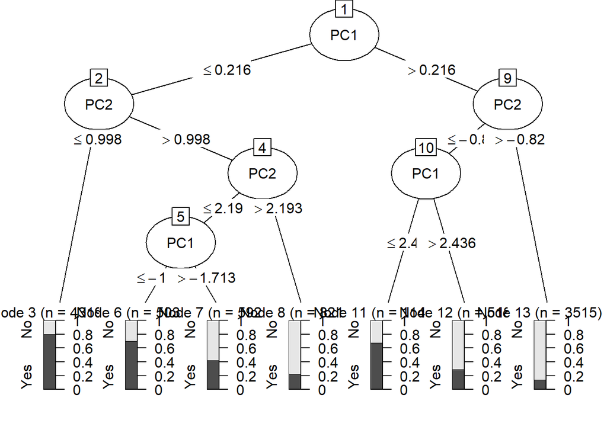

```r
model_pruning <- C50::C5.0(trainX, trainy, control = C5.0Control(minCases=500))
plot(model_pruning)
```

Comprobamos como este árbol si que es posible de comprender e interpretar.

**Validación del árbol**

```r
predicted_model <- predict( model_pruning, testX, type="class" )
# Denotamos como positive, los registros que tenemos impagos
confusionMatrix(data = predicted_model, reference = as.factor(testy), positive = 'Yes')
```

```
## Confusion Matrix and Statistics
##
##           Reference
## Prediction   No  Yes
##        No  2129  529
##        Yes  738 2311
##
##                Accuracy : 0.778
##                  95% CI : (0.767, 0.7887)
##     No Information Rate : 0.5024
##     P-Value [Acc > NIR] : < 2.2e-16
##
##                   Kappa : 0.5561
##
##  Mcnemar's Test P-Value : 5.111e-09
##
##             Sensitivity : 0.8137
##             Specificity : 0.7426
##          Pos Pred Value : 0.7580
##          Neg Pred Value : 0.8010
##              Prevalence : 0.4976
##          Detection Rate : 0.4049
##    Detection Prevalence : 0.5343
##       Balanced Accuracy : 0.7782
##
##        'Positive' Class : Yes
##
```

Como podemos ver en el apartado Accuracy, que hace referencia a la exactitud, es decir, el número de registros clasificados correctamente, es del 77.8% y por lo tanto, un error del 22.2%, un poco más alto que en la fase de entrenamineto. Ambos valores son un poco peores que los conseguidos con el modelo sin poda, sin embargo podemos apreciar que el árbol creado es menos específico, se adapta mejor a datos nuevos, ya que el error ha aumentado menos que en caso anterior. Pues en el primer caso aumentó un 3% y en este caso el 0.6%. Analizando los dos tipos de error nos damos cuenta que el que nos aporta información relevante para este caso es el error de tipo II, ya que será el que nos permitirá conocer lo de días que va a llover. De cara al dataset, este modelo tiene una sensibilad del 81.37%. Es decir, somos capaces de predecir el 81.37% de los días que va a llover, el cual es un buen dato.

Ahora vamos a crear un arbol en el que combinamos el booting y la poda

Boosting

El Boosting se basa en la noción de que al combinar una serie de learners con bajo rendimiento, se puede crear un equipo que sea mucho más fuerte que cualquiera de los learners solos. Cada uno de los modelos tiene un conjunto único de fortalezas y debilidades y pueden ser mejores o peores para resolver ciertos problemas. El uso de una combinación de varios learners con fortalezas y debilidades complementarias puede, por lo tanto, mejorar dramáticamente la precisión de un clasificador. La función C5.0 () facilita agregar el boosting a nuestro árbol de decisión C5.0. Simplemente necesitamos agregar un parámetro de prueba adicional que indique el número de árboles de decisión separados para usar en el equipo de boosting.

**Entrenamiento del árbol**

```r
# El núemro de árboles lo indicamos con trials
modelo_boosting <- C50::C5.0(trainX, trainy, trials = 5, rules=TRUE, control = C5.0Control(minCases = 500))
summary(modelo_boosting)
```

```
##
## Call:
## C5.0.default(x = trainX, y = trainy, trials = 5, rules = TRUE, control
##  = C5.0Control(minCases = 500))
##
##
## C5.0 [Release 2.07 GPL Edition]      Sat Apr 08 10:03:41 2023
## -------------------------------
##
## Class specified by attribute `outcome'
##
## Read 11412 cases (7 attributes) from undefined.data
##
## -----  Trial 0:  -----
##
## Rules:
##
## Rule 0/1: (1577/181, lift 1.7)
##  PC1 > 2.436041
##  ->  class No  [0.885]
##
## Rule 0/2: (3515/486, lift 1.7)
##  PC1 > 0.2156888
##  PC2 > -0.8202851
##  ->  class No  [0.862]
##
## Rule 0/3: (3487/888, lift 1.5)
##  PC2 > 0.9977986
##  ->  class No  [0.745]
##
## Rule 0/4: (2356/347, lift 1.7)
##  PC1 <= -1.713371
##  PC2 <= 2.192885
##  ->  class Yes  [0.852]
##
## Rule 0/5: (3354/670, lift 1.6)
##  PC1 <= 2.436041
##  PC2 <= -0.8202851
##  ->  class Yes  [0.800]
##
```

[output cut: 131 more lines]

```
##    4424  1352    (a): class No
##    1010  4626    (b): class Yes
##
##
##  Attribute usage:
##
##  100.00% PC1
##  100.00% PC2
##   62.98% PC6
##   46.01% PC5
##   33.36% PC3
##   33.36% PC4
##
##
## Time: 0.3 secs
```

Rule 0/1: PC1 > 2.436041 -> No llueve al dia siguiente. Validez: 88.5%

Rule 2/1: PC2 > 3.030732 -> No llueve al dia siguiente. Validez: 88.7%

Rule 3/3: PC1 <= -1.664893, PC2 <= 1.834343 -> Llueve al dia siguiente. Validez: 86.3%

Rule 0/4: PC1 <= -1.713371, PC2 <= 2.192885 -> Llueve al dia siguiente. Validez: 85.2%

Rule 0/5: PC1 <= 2.436041, PC2 <= -0.8202851 -> Llueve al dia siguiente. Validez: 80%

A las conclusiones que llegamos son basatante similiares a las que hemos llegado en los casos anteriores. Por lo que también podríamos decir que para un registro que al día siguiente no vaya a llover, los valores de PC1 > 0 y PC2 > 0, es decir, cunado no va llover al día siguiente PC1 y PC2 son positivos y cuando va llover negativos.